# Analysis - SMC Paper Structured

### Inhalation Amplitude

```r
dat <- brm %>%
  filter(Role=="Participant", Task=="Free", act=="speaking")
```

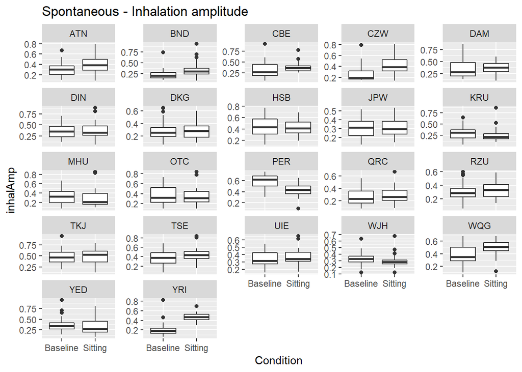

```r
ggplot(dat %>% filter(Condition %in% c("Baseline", "Sitting")), aes(Condition, inhalAmp))+
  geom_boxplot()+
  facet_wrap(~Speaker, scales="free_y")+
  ggtitle("Spontaneous - Inhalation amplitude")
```

```r
ggsave(paste0(folderInd, "Spontaneous-InhalAmp-BaselineInteraction.png"), width = 3000, height=3000, units="px")
```

A few speakers had deeper inhalations during Sitting, others the opposite. In general, not a big difference across conditions.

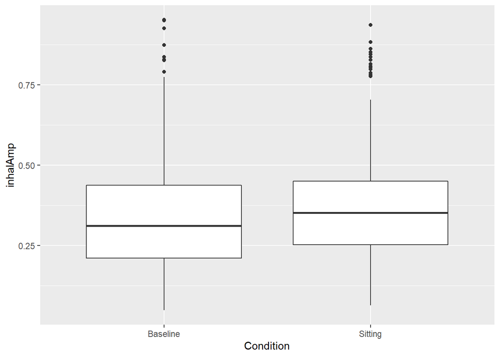

```r
ggplot(dat %>% filter(Condition %in% c("Baseline", "Sitting")), aes(Condition, inhalAmp))+
  geom_boxplot()
```

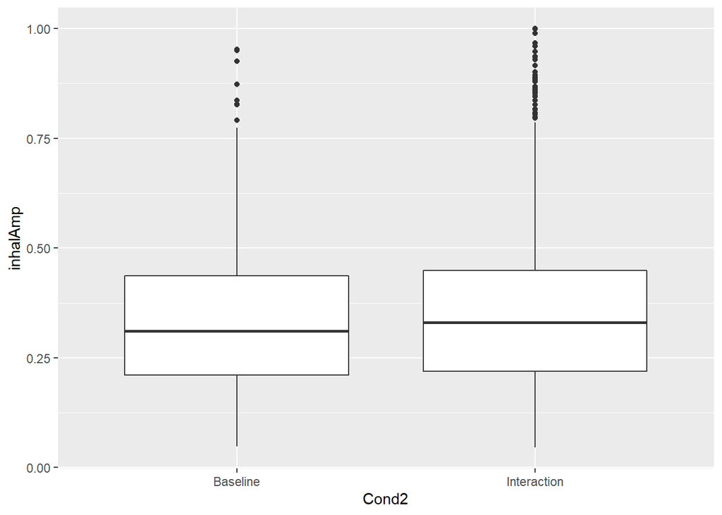

```r
ggplot(dat, aes(Cond2, inhalAmp))+
  geom_boxplot()
```

- Inhalation amplitude doesn’t change between Baseline and Sitting or Baseline and Interaction during solo spontaneous speech.

```r
summary(b1 <- lmer(inhalAmp ~ Condition + (1+Condition| Speaker), dat %>% filter(Condition %in% c("Baseline", "Sitting"))))
```

```
## Linear mixed model fit by REML ['lmerMod']
## Formula: inhalAmp ~ Condition + (1 + Condition | Speaker)
##    Data: dat %>% filter(Condition %in% c("Baseline", "Sitting"))
##
## REML criterion at convergence: -1011.7
##
## Scaled residuals:
##     Min      1Q  Median      3Q     Max
## -2.2402 -0.6783 -0.1010  0.5222  3.9558
##
## Random effects:
##  Groups   Name             Variance Std.Dev. Corr
##  Speaker  (Intercept)      0.004730 0.06877
##           ConditionSitting 0.003829 0.06188  -0.62
##  Residual                  0.023123 0.15206
## Number of obs: 1175, groups:  Speaker, 22
##
## Fixed effects:
##                  Estimate Std. Error t value
## (Intercept)       0.34213    0.01614  21.203
## ConditionSitting  0.02635    0.01621   1.626
##
## Correlation of Fixed Effects:
##             (Intr)
## CondtnSttng -0.630
```

```r
summary(b1 <- lmer(inhalAmp ~ Cond2 + (1+Cond2| Speaker), dat))
```

```
## Linear mixed model fit by REML ['lmerMod']
## Formula: inhalAmp ~ Cond2 + (1 + Cond2 | Speaker)
##    Data: dat
##
## REML criterion at convergence: -1679.9
##
## Scaled residuals:
##     Min      1Q  Median      3Q     Max
## -2.4863 -0.6819 -0.1358  0.5287  4.2072
##
## Random effects:
##  Groups   Name             Variance Std.Dev. Corr
##  Speaker  (Intercept)      0.004486 0.06698
##           Cond2Interaction 0.003661 0.06051  -0.48
##  Residual                  0.026575 0.16302
## Number of obs: 2249, groups:  Speaker, 22
##
## Fixed effects:
##                  Estimate Std. Error t value
## (Intercept)       0.34134    0.01599  21.351
## Cond2Interaction  0.02727    0.01536   1.776
##
## Correlation of Fixed Effects:
##             (Intr)
## Cnd2Intrctn -0.568
```

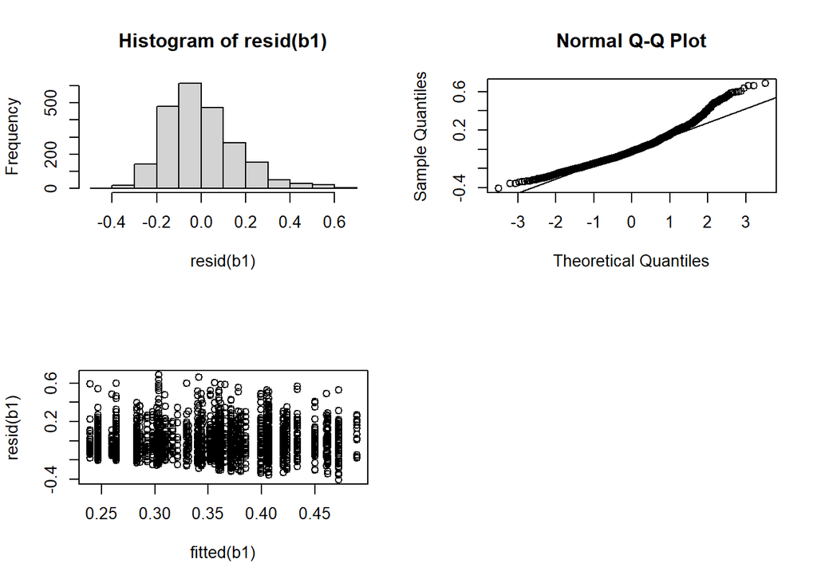

```r
par(mfrow=c(2, 2))
hist(resid(b1))
qqnorm(resid(b1));qqline(resid(b1))
plot(fitted(b1), resid(b1))
```

# 1 - Speech. Is there a difference in speech behavior (f0) when people talk alone or in an interaction?

## Solo read speech

```r
dat <- frb %>%
  filter(Role=="Participant", Task%in%c("ReadAlone", "ReadBaseline"))
```

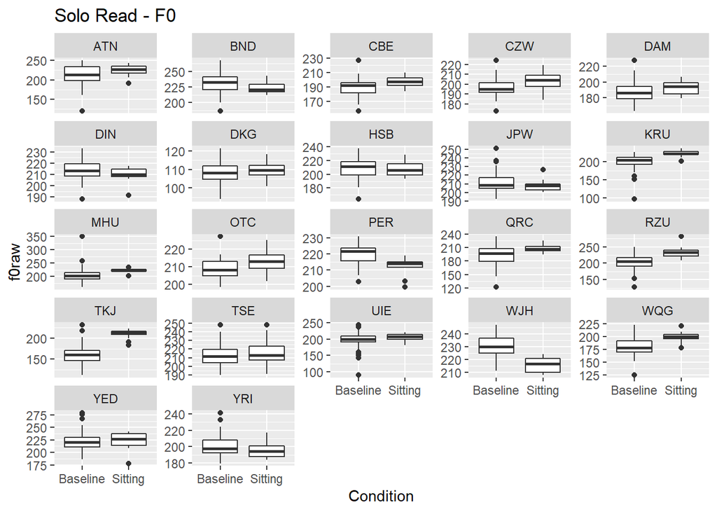

```r
ggplot(dat %>% filter(Condition %in% c("Baseline", "Sitting")), aes(Condition, f0raw))+
  geom_boxplot()+
  facet_wrap(~Speaker, scales="free_y")+
  ggtitle("Solo Read - F0")
```

```r
ggsave(paste0(folderInd, "SoloRead-F0-BaselineInteraction.png"), width = 3000, height=3000, units="px")
```

Some participants had higher f0 during Sitting, only a couple the opposite. The difference between the conditions wasn’t big.

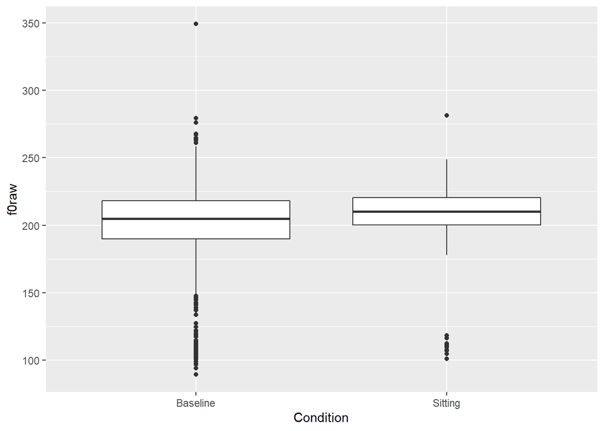

```r
ggplot(dat %>% filter(Condition %in% c("Baseline", "Sitting")), aes(Condition, f0raw))+
  geom_boxplot()
```

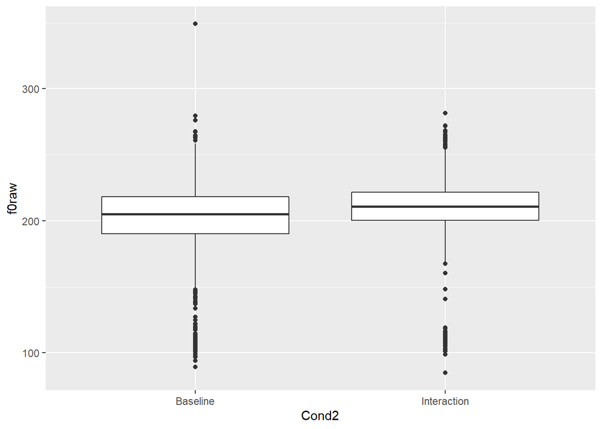

```r
ggplot(dat, aes(Cond2, f0raw))+
  geom_boxplot()
```

- F0 was higher during interaction than during baseline. (This is considering baseline vs. sitting AND baseline vs. interaction)

```r
summary(f1 <- lmer(f0raw ~ Condition + (1 + Condition | Speaker), dat %>% filter(Condition %in% c("Baseline", "Sitting"))))
```

```
## Linear mixed model fit by REML ['lmerMod']
## Formula: f0raw ~ Condition + (1 + Condition | Speaker)
##    Data: dat %>% filter(Condition %in% c("Baseline", "Sitting"))
##
## REML criterion at convergence: 15032.7
##
## Scaled residuals:
##     Min      1Q  Median      3Q     Max
## -7.0017 -0.4937  0.0074  0.4911  9.0325
##
## Random effects:
##  Groups   Name             Variance Std.Dev. Corr
##  Speaker  (Intercept)      687.4    26.22
##           ConditionSitting 191.8    13.85    -0.43
##  Residual                  242.9    15.59
## Number of obs: 1785, groups:  Speaker, 22
##
## Fixed effects:
##                  Estimate Std. Error t value
## (Intercept)       199.867      5.612  35.617
## ConditionSitting    7.374      3.063   2.408
##
## Correlation of Fixed Effects:
##             (Intr)
## CondtnSttng -0.422
```

```r
summary(f1a <- lmer(f0raw ~ Cond2 + (1 + Cond2 | Speaker), dat))
```

```
## Linear mixed model fit by REML ['lmerMod']
## Formula: f0raw ~ Cond2 + (1 + Cond2 | Speaker)
##    Data: dat
##
## REML criterion at convergence: 26206
##
## Scaled residuals:
##     Min      1Q  Median      3Q     Max
## -7.5155 -0.5329  0.0205  0.5039  9.7011
##
## Random effects:
##  Groups   Name             Variance Std.Dev. Corr
##  Speaker  (Intercept)      688.0    26.23
##           Cond2Interaction 149.0    12.20    -0.36
##  Residual                  210.8    14.52
## Number of obs: 3177, groups:  Speaker, 22
##
## Fixed effects:
##                  Estimate Std. Error t value
## (Intercept)       199.867      5.611  35.620
## Cond2Interaction    7.383      2.664   2.772
##
## Correlation of Fixed Effects:
##             (Intr)
## Cnd2Intrctn -0.361
```

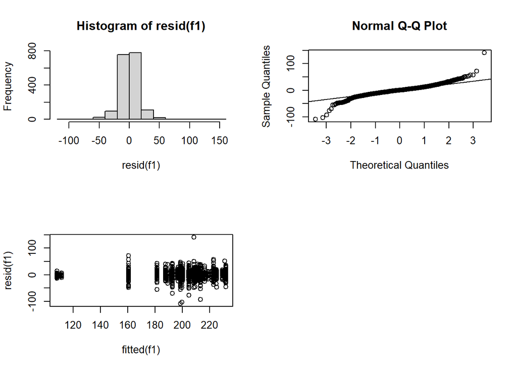

```r
par(mfrow=c(2, 2))
hist(resid(f1))
qqnorm(resid(f1));qqline(resid(f1))
plot(fitted(f1), resid(f1))

par(mfrow=c(2, 2))
```

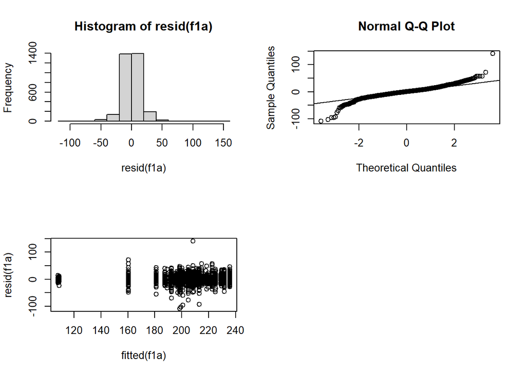

```r
hist(resid(f1a))
qqnorm(resid(f1a));qqline(resid(f1a))
plot(fitted(f1a), resid(f1a))
```

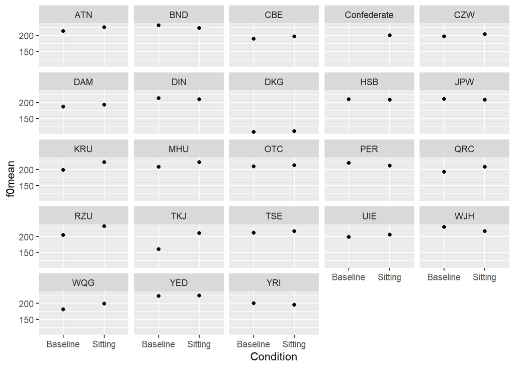

```r
dat <- frb %>%
  filter(Task %in% c("ReadAlone", "ReadBaseline"), Condition %in% c("Baseline", "Sitting")) %>%
  group_by(Speaker, Condition) %>%
  mutate(f0mean = mean(f0raw, na.rm=TRUE)) %>%
  ungroup()

ggplot(dat, aes(Condition, f0mean))+
  geom_point()+
  geom_line()+
  facet_wrap(~Speaker)
```

## Solo spontaneous speech

```r
dat <- fsm %>%
  filter(Role=="Participant", Task=="Free")
```

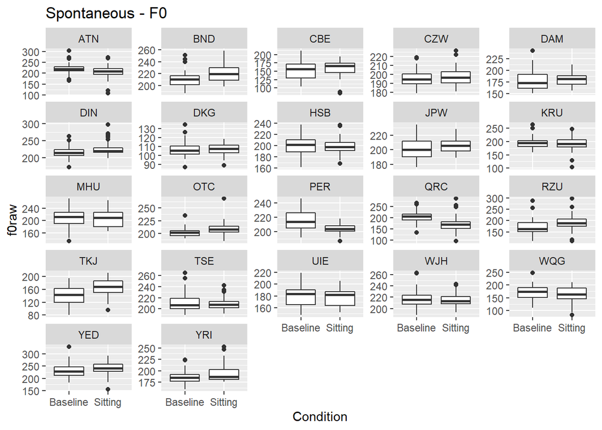

```r
ggplot(dat %>% filter(Condition %in% c("Baseline", "Sitting")), aes(Condition, f0raw))+
  geom_boxplot()+
  facet_wrap(~Speaker, scales="free_y")+
  ggtitle("Spontaneous - F0")
```

```r
ggsave(paste0(folderInd, "Spontaneous-f0-BaselineInteraction.png"), width = 3000, height=3000, units="px")
```

A few had higher f0 during Sitting. Only a couple the opposite. Mostly no difference.

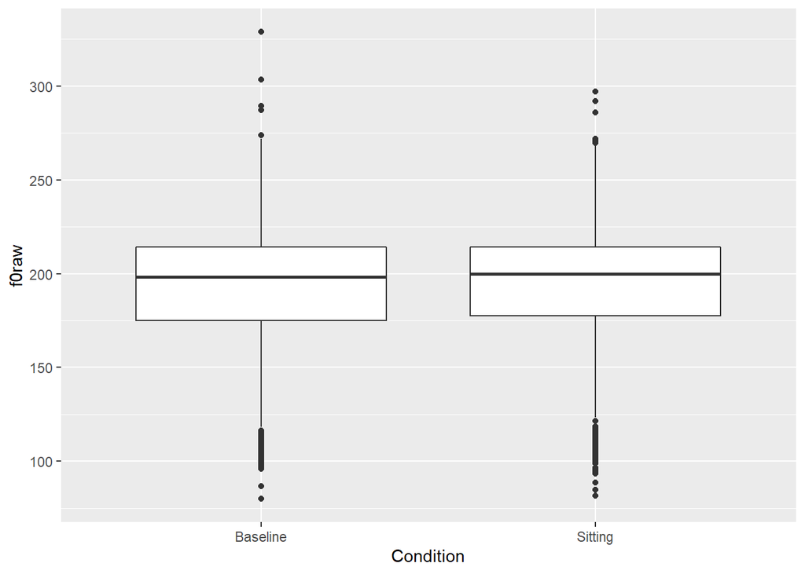

```r
ggplot(dat %>% filter(Condition %in% c("Baseline", "Sitting")), aes(Condition, f0raw))+
  geom_boxplot()
```

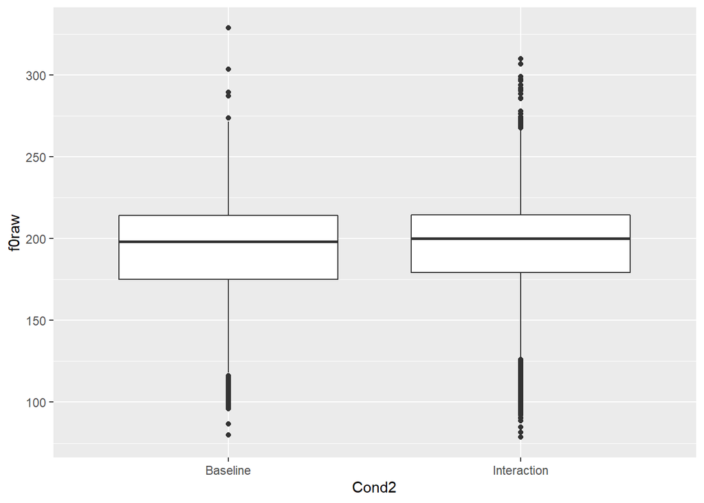

```r
ggplot(dat, aes(Cond2, f0raw))+
  geom_boxplot()
```

- F0 didn’t change from Baseline to Interaction OR from Baseline to Sitting.

```r
summary(f1 <- lmer(f0raw ~ Condition + (1 + Condition | Speaker), dat %>% filter(Condition %in% c("Baseline", "Sitting"))))
```

```
## Linear mixed model fit by REML ['lmerMod']
## Formula: f0raw ~ Condition + (1 + Condition | Speaker)
##    Data: dat %>% filter(Condition %in% c("Baseline", "Sitting"))
##
## REML criterion at convergence: 19441.6
##
## Scaled residuals:
##     Min      1Q  Median      3Q     Max
## -4.6706 -0.5320 -0.0350  0.5066  5.4153
##
## Random effects:
##  Groups   Name             Variance Std.Dev. Corr
##  Speaker  (Intercept)      851.4    29.18
##           ConditionSitting 125.4    11.20    -0.29
##  Residual                  441.9    21.02
## Number of obs: 2161, groups:  Speaker, 22
##
## Fixed effects:
##                  Estimate Std. Error t value
## (Intercept)       191.603      6.257  30.622
## ConditionSitting    1.470      2.571   0.572
##
## Correlation of Fixed Effects:
##             (Intr)
## CondtnSttng -0.293
```

```r
summary(f1a <- lmer(f0raw ~ Cond2 + (1 + Cond2 | Speaker), dat))
```

```
## Linear mixed model fit by REML ['lmerMod']
## Formula: f0raw ~ Cond2 + (1 + Cond2 | Speaker)
##    Data: dat
##
## REML criterion at convergence: 38089
##
## Scaled residuals:
##     Min      1Q  Median      3Q     Max
## -5.2119 -0.5034 -0.0207  0.4996  5.5838
##
## Random effects:
##  Groups   Name             Variance Std.Dev. Corr
##  Speaker  (Intercept)      851.1    29.17
##           Cond2Interaction 139.6    11.82    -0.33
##  Residual                  434.2    20.84
## Number of obs: 4255, groups:  Speaker, 22
##
## Fixed effects:
##                  Estimate Std. Error t value
## (Intercept)       191.594      6.255  30.629
## Cond2Interaction    1.251      2.636   0.475
##
## Correlation of Fixed Effects:
##             (Intr)
## Cnd2Intrctn -0.342
```

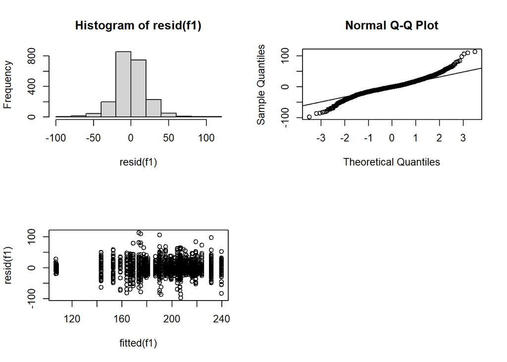

```r
par(mfrow=c(2, 2))
hist(resid(f1))
qqnorm(resid(f1));qqline(resid(f1))
plot(fitted(f1), resid(f1))

par(mfrow=c(2, 2))
```

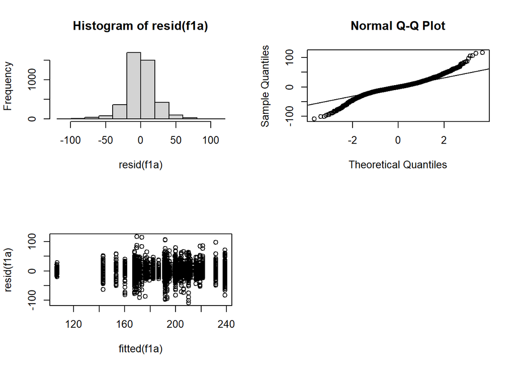

```r
hist(resid(f1a))
qqnorm(resid(f1a));qqline(resid(f1a))
plot(fitted(f1a), resid(f1a))
```

# 2 - Breathing without overlapping speech

# 2.1 Do speakers adapt their speech breathing to an interlocutor who moves with different physical effort?

## Solo read speech

### Cycle Duration

```r
dat <- brm %>%
  filter(Role=="Participant", Task%in%c("ReadAlone", "ReadBaseline"), Condition!="Baseline")
```

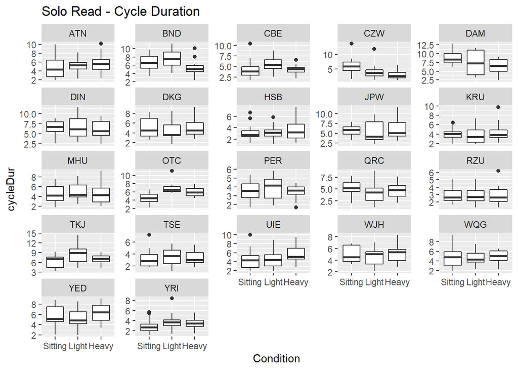

```r
ggplot(dat, aes(Condition, cycleDur))+
  geom_boxplot()+
  facet_wrap(~Speaker, scales="free_y")+
  ggtitle("Solo Read - Cycle Duration")
```

```r
ggsave(paste0(folderInd, "SoloRead-CycleDur-Conditions.png"), width = 3000, height=3000, units="px")
```

For some of the participants, Light seemed to be the most different condition. But in general, no difference across conditions for most participants.

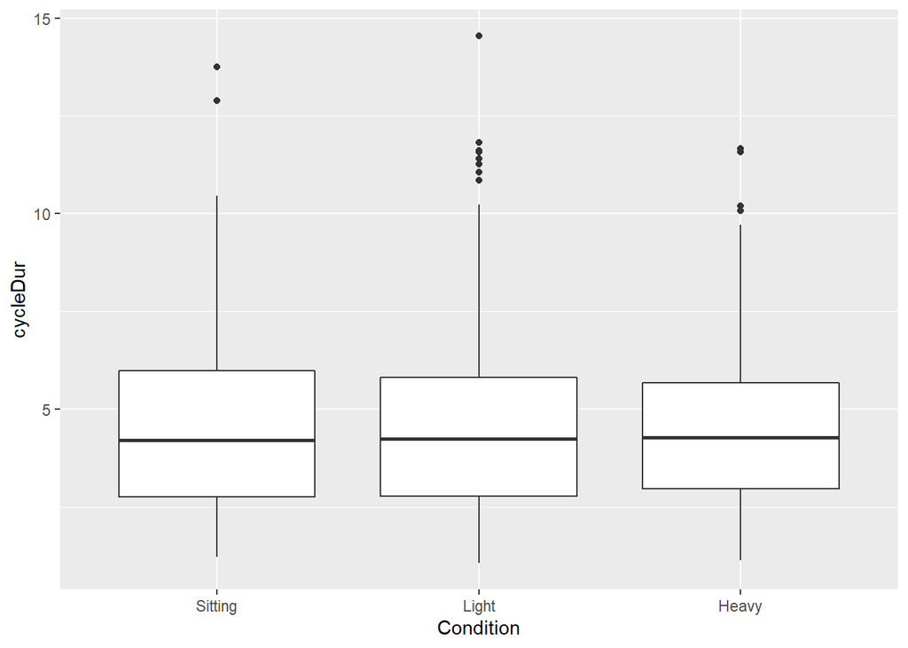

```r
ggplot(dat, aes(Condition, cycleDur))+
  geom_boxplot()
```

- There is no effect of condition on cycle duration during solo read speech.

```r
# dat$Condition <- relevel(dat$Condition, ref="Light")
summary(b1 <- lmer(cycleDur ~ Condition + (1+Condition| Speaker), dat))
```

```
## Linear mixed model fit by REML ['lmerMod']
## Formula: cycleDur ~ Condition + (1 + Condition | Speaker)
##    Data: dat
##
## REML criterion at convergence: 3522.1
##
## Scaled residuals:
##     Min      1Q  Median      3Q     Max
## -2.3943 -0.6848 -0.0937  0.5466  5.0218
##
## Random effects:
##  Groups   Name           Variance Std.Dev. Corr
##  Speaker  (Intercept)    1.5235   1.2343
##           ConditionLight 0.0122   0.1104    1.00
##           ConditionHeavy 0.2531   0.5031   -0.36 -0.36
##  Residual                3.5364   1.8805
## Number of obs: 841, groups:  Speaker, 22
##
## Fixed effects:
##                Estimate Std. Error t value
## (Intercept)    4.852837   0.286806  16.920
## ConditionLight 0.147376   0.162009   0.910
## ConditionHeavy 0.004152   0.193264   0.021
##
## Correlation of Fixed Effects:
##             (Intr) CndtnL
## ConditnLght -0.140
## ConditinHvy -0.417  0.379
## optimizer (nloptwrap) convergence code: 0 (OK)
## boundary (singular) fit: see help('isSingular')
```

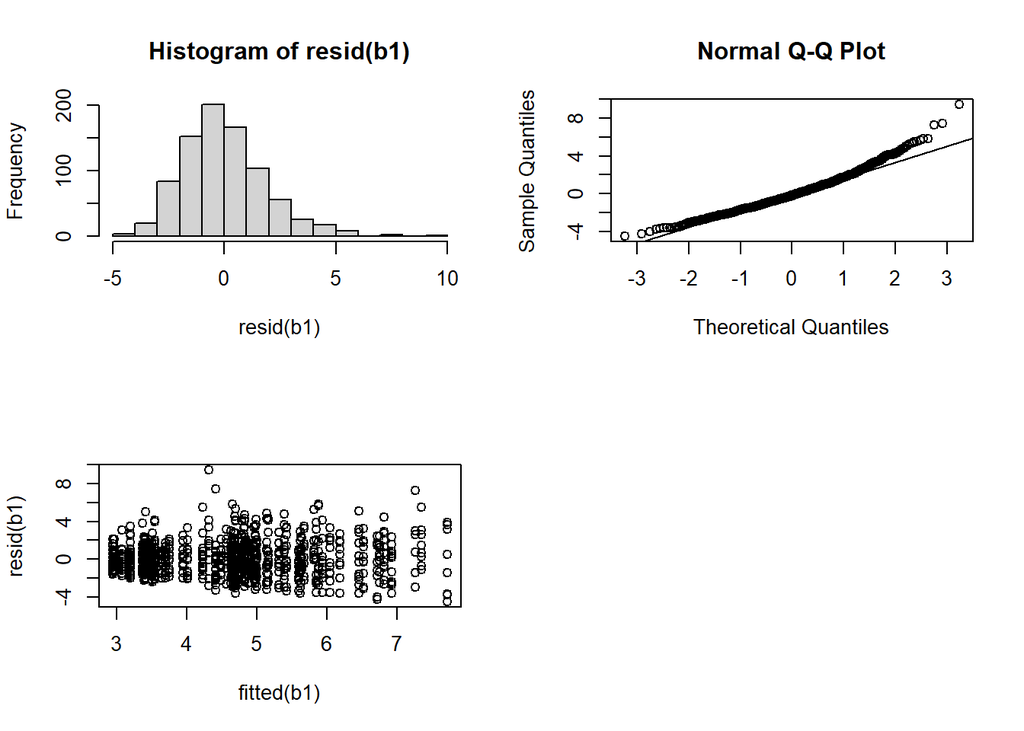

```r
par(mfrow=c(2, 2))
hist(resid(b1))
qqnorm(resid(b1));qqline(resid(b1))
plot(fitted(b1), resid(b1))
```

### Inhalation Amplitude

```r
dat <- brm %>%
  filter(Role=="Participant", Task%in%c("ReadAlone", "ReadBaseline"), Condition!="Baseline")
```

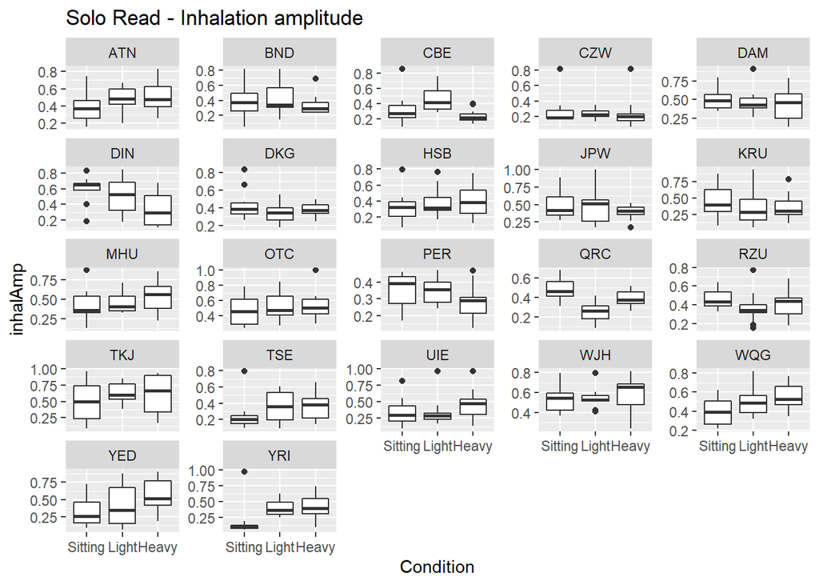

```r
ggplot(dat, aes(Condition, inhalAmp))+
  geom_boxplot()+
  facet_wrap(~Speaker, scales="free_y")+
  ggtitle("Solo Read - Inhalation amplitude")
```

```r
ggsave(paste0(folderInd, "SoloRead-InhalAmp-Conditions.png"), width = 3000, height=3000, units="px")
```

For quite a few participants, inhalation amplitude seemed to go up with physical effort. For one, the opposite (but very markedly). For many, no difference.

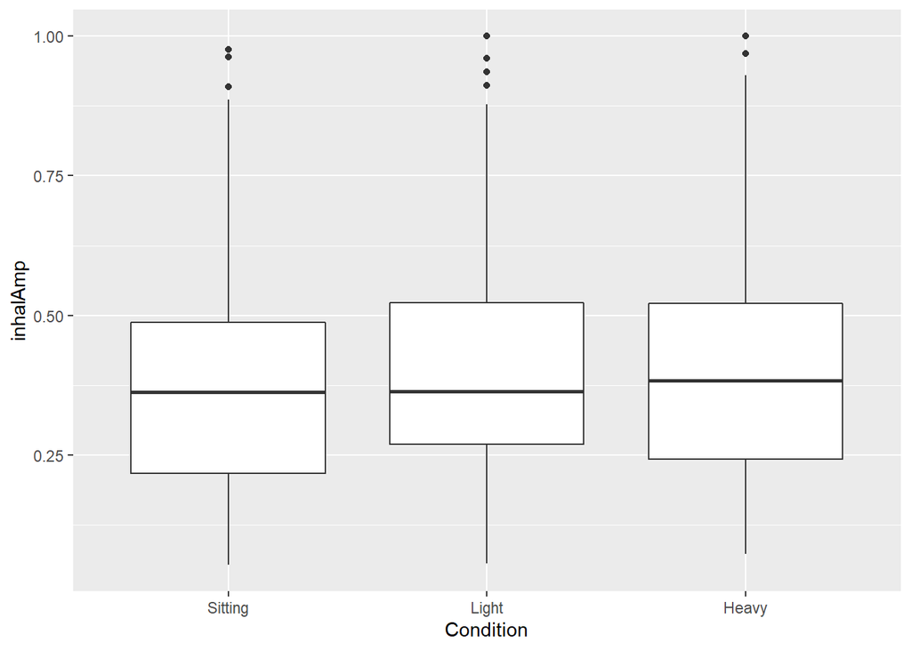

```r
ggplot(dat, aes(Condition, inhalAmp))+
  geom_boxplot()
```

- There is no effect of condition on inhalation amplitude during solo read speech.

```r
# dat$Condition <- relevel(dat$Condition, ref="Light")
summary(b1 <- lmer(inhalAmp ~ Condition + (1+Condition| Speaker), dat))
```

```
## Linear mixed model fit by REML ['lmerMod']
## Formula: inhalAmp ~ Condition + (1 + Condition | Speaker)
##    Data: dat
##
## REML criterion at convergence: -454.3
##
## Scaled residuals:
##     Min      1Q  Median      3Q     Max
## -2.3554 -0.6432 -0.1422  0.5401  4.4899
##
## Random effects:
##  Groups   Name           Variance Std.Dev. Corr
##  Speaker  (Intercept)    0.009425 0.09708
##           ConditionLight 0.007713 0.08783  -0.61
##           ConditionHeavy 0.011282 0.10622  -0.52  0.83
##  Residual                0.030316 0.17411
## Number of obs: 841, groups:  Speaker, 22
##
## Fixed effects:
##                Estimate Std. Error t value
## (Intercept)     0.39739    0.02331  17.046
## ConditionLight  0.02122    0.02408   0.881
## ConditionHeavy  0.02581    0.02722   0.948
##
## Correlation of Fixed Effects:
##             (Intr) CndtnL
## ConditnLght -0.627
## ConditinHvy -0.567  0.717
```

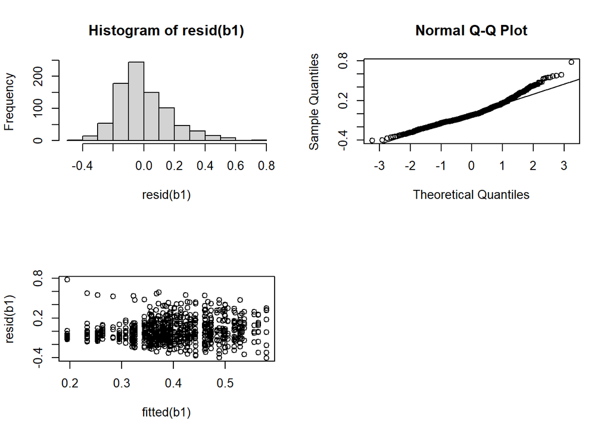

```r
par(mfrow=c(2, 2))
hist(resid(b1))
qqnorm(resid(b1));qqline(resid(b1))
plot(fitted(b1), resid(b1))
```

## Solo spontaneous speech

### Cycle Duration

```r
dat <- brm %>%
  filter(Role=="Participant", Task=="Free", act=="speaking", Condition!="Baseline")
```

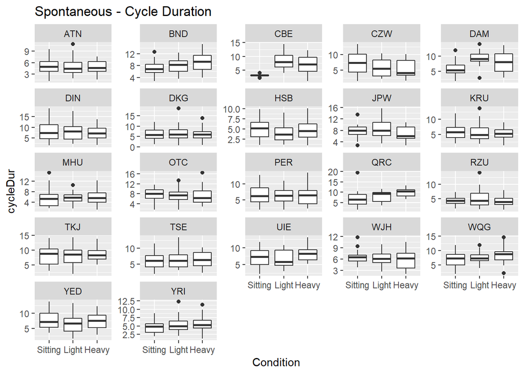

```r
ggplot(dat, aes(Condition, cycleDur))+
  geom_boxplot()+
  facet_wrap(~Speaker, scales="free_y")+
  ggtitle("Spontaneous - Cycle Duration")
```

```r
ggsave(paste0(folderInd, "Spontaneous-CycleDur-Conditions.png"), width = 3000, height=3000, units="px")
```

For almost all participants, no difference.

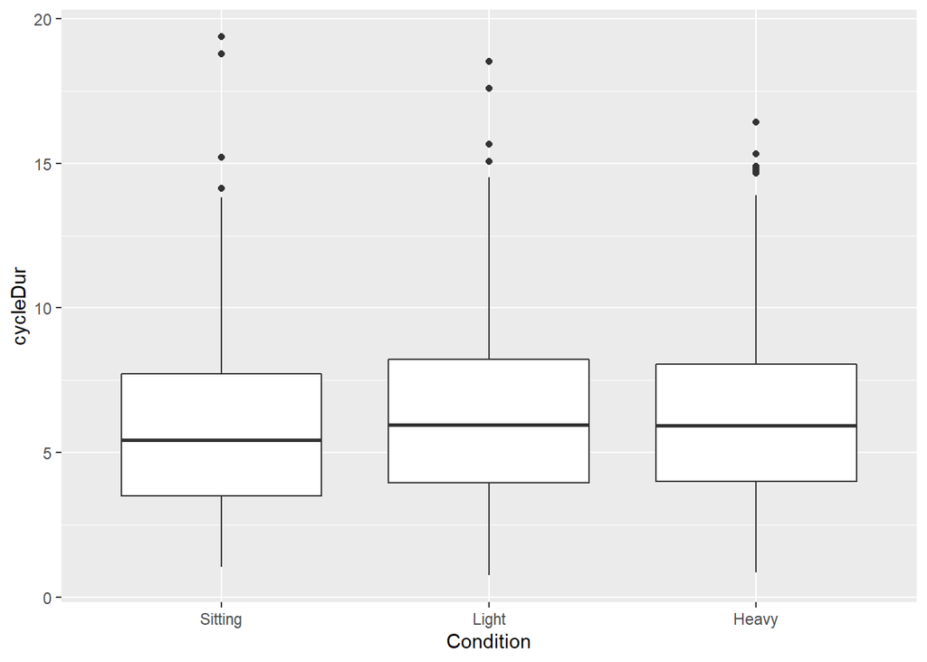

```r
ggplot(dat, aes(Condition, cycleDur))+
  geom_boxplot()
```

- There is no effect of condition on cycle duration during solo spontaneous speech.

```r
# dat$Condition <- relevel(dat$Condition, ref="Light")
summary(b1 <- lmer(cycleDur ~ Condition + (1+Condition| Speaker), dat))
```

```
## Linear mixed model fit by REML ['lmerMod']
## Formula: cycleDur ~ Condition + (1 + Condition | Speaker)
##    Data: dat
##
## REML criterion at convergence: 8036.1
##
## Scaled residuals:
##     Min      1Q  Median      3Q     Max
## -2.3861 -0.6852 -0.0683  0.6039  4.7116
##
## Random effects:
##  Groups   Name           Variance Std.Dev. Corr
##  Speaker  (Intercept)    1.599    1.265
##           ConditionLight 1.384    1.176    -0.51
##           ConditionHeavy 1.341    1.158    -0.32  0.98
##  Residual                6.819    2.611
## Number of obs: 1670, groups:  Speaker, 22
##
## Fixed effects:
##                Estimate Std. Error t value
## (Intercept)      6.2909     0.2930  21.473
## ConditionLight   0.3726     0.3000   1.242
## ConditionHeavy   0.4213     0.2969   1.419
##
## Correlation of Fixed Effects:
##             (Intr) CndtnL
## ConditnLght -0.545
## ConditinHvy -0.392  0.837
## optimizer (nloptwrap) convergence code: 0 (OK)
## boundary (singular) fit: see help('isSingular')
```

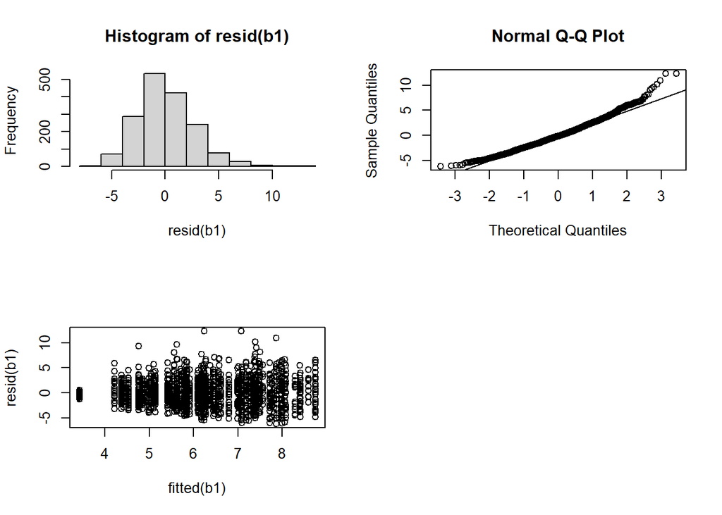

```r
par(mfrow=c(2, 2))
hist(resid(b1))
qqnorm(resid(b1));qqline(resid(b1))
plot(fitted(b1), resid(b1))
```

### Inhalation Amplitude

```r
dat <- brm %>%
  filter(Role=="Participant", Task=="Free", act=="speaking", Condition!="Baseline")
```

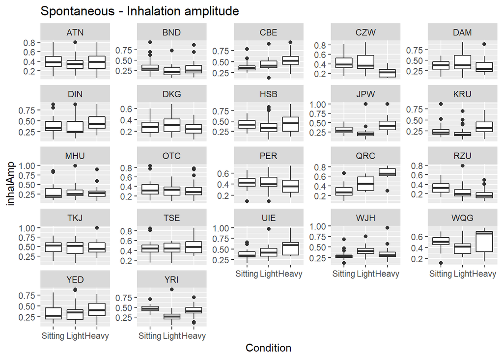

```r
ggplot(dat, aes(Condition, inhalAmp))+
  geom_boxplot()+
  facet_wrap(~Speaker, scales="free_y")+
  ggtitle("Spontaneous - Inhalation amplitude")
```

```r
ggsave(paste0(folderInd, "Spontaneous-InhalAmp-Conditions.png"), width = 3000, height=3000, units="px")
```

For a few participants, there was either a decrease or increase in inhalation amplitude with physical effort. For a couple, it seemed non-linear. For the others, no difference.

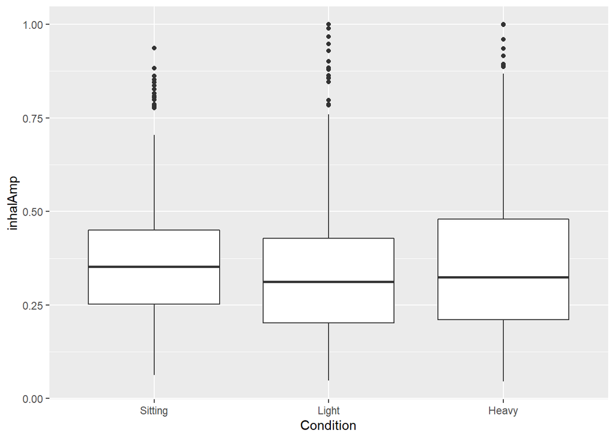

```r
ggplot(dat, aes(Condition, inhalAmp))+
  geom_boxplot()
```

- There is no effect of condition on inhalation amplitude during solo spontaneous speech.

```r
# dat$Condition <- relevel(dat$Condition, ref="Light")
summary(b1 <- lmer(inhalAmp ~ Condition + (1+Condition| Speaker), dat))
```

```
## Linear mixed model fit by REML ['lmerMod']
## Formula: inhalAmp ~ Condition + (1 + Condition | Speaker)
##    Data: dat
##
## REML criterion at convergence: -1298.9
##
## Scaled residuals:
##     Min      1Q  Median      3Q     Max
## -2.5045 -0.6391 -0.1063  0.5215  4.5164
##
## Random effects:
##  Groups   Name           Variance Std.Dev. Corr
##  Speaker  (Intercept)    0.003182 0.05641
##           ConditionLight 0.003996 0.06321  -0.20
##           ConditionHeavy 0.010755 0.10370  -0.13  0.54
##  Residual                0.024894 0.15778
## Number of obs: 1670, groups:  Speaker, 22
##
## Fixed effects:
##                Estimate Std. Error t value
## (Intercept)     0.36862    0.01385  26.609
## ConditionLight -0.00923    0.01682  -0.549
## ConditionHeavy  0.02844    0.02434   1.169
##
## Correlation of Fixed Effects:
##             (Intr) CndtnL
## ConditnLght -0.343
## ConditinHvy -0.242  0.507
```

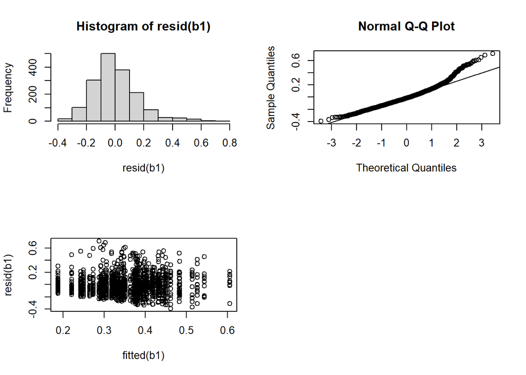

```r
par(mfrow=c(2, 2))
hist(resid(b1))
qqnorm(resid(b1));qqline(resid(b1))
plot(fitted(b1), resid(b1))
```

# 2.2 Do speakers adapt their breathing while listening to an interlocutor who moves and talks with different physical effort?

### Cycle Duration

```r
dat <- brm %>%
  filter(Role=="Participant", act == "listening")
```

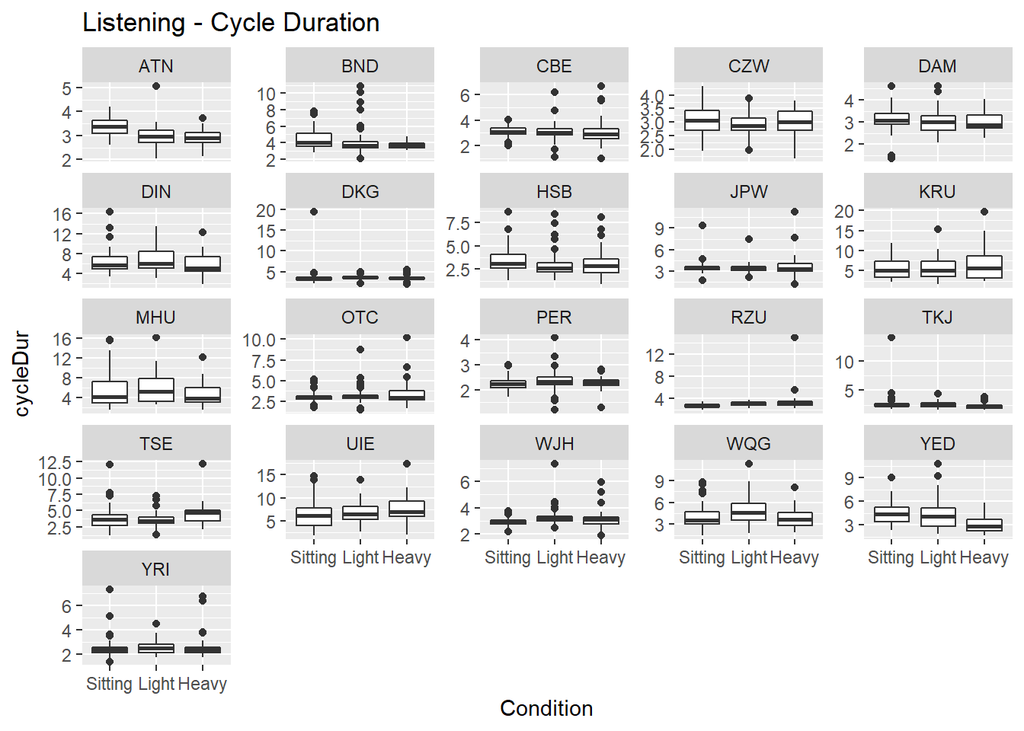

```r
ggplot(dat, aes(Condition, cycleDur))+
  geom_boxplot()+
  facet_wrap(~Speaker, scales="free_y")+
  ggtitle("Listening - Cycle Duration")
```

```r
ggsave(paste0(folderInd, "Listening-CycleDur-Conditions.png"), width = 3000, height=3000, units="px")
```

No difference.

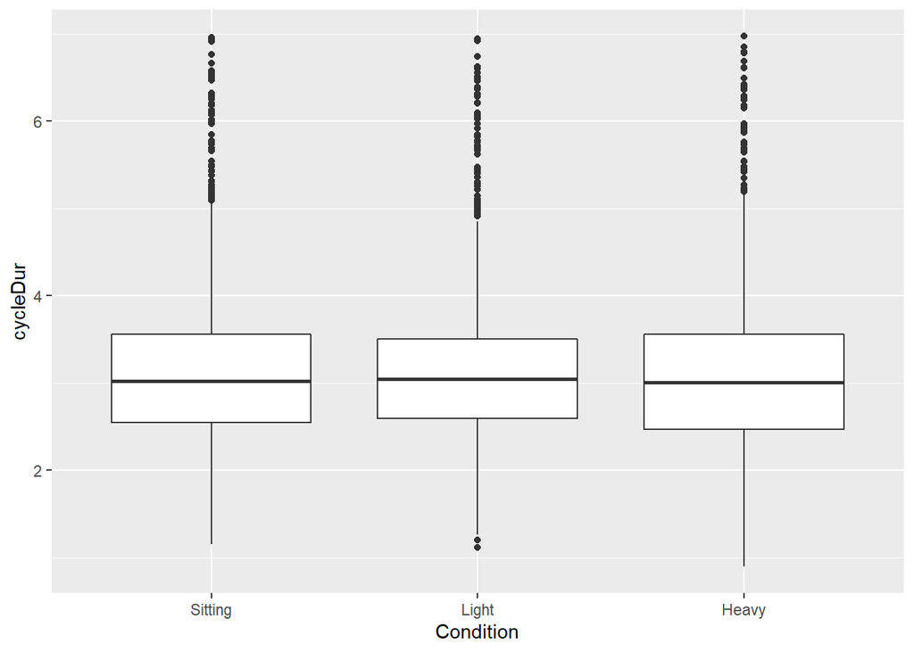

```r
ggplot(dat %>% filter(cycleDur < 7), aes(Condition, cycleDur))+
  geom_boxplot()
```

- Cycle duration doesn’t change across conditions during listening.

```r
summary(c1 <- lmer(cycleDur ~ Condition + (1 + Condition |Speaker), dat))
```

```
## Linear mixed model fit by REML ['lmerMod']
## Formula: cycleDur ~ Condition + (1 + Condition | Speaker)
##    Data: dat
##
## REML criterion at convergence: 10961.3
##
## Scaled residuals:
##     Min      1Q  Median      3Q     Max
## -3.8378 -0.3344 -0.0829  0.1805 11.1356
##
## Random effects:
##  Groups   Name           Variance Std.Dev. Corr
##  Speaker  (Intercept)    1.649715 1.28441
##           ConditionLight 0.009904 0.09952   0.61
##           ConditionHeavy 0.350460 0.59200  -0.07  0.75
##  Residual                1.997215 1.41323
## Number of obs: 3066, groups:  Speaker, 21
##
## Fixed effects:
##                Estimate Std. Error t value
## (Intercept)     3.84687    0.28350  13.569
## ConditionLight  0.01217    0.06358   0.191
## ConditionHeavy -0.05089    0.14542  -0.350
##
## Correlation of Fixed Effects:
##             (Intr) CndtnL
## ConditnLght  0.109
## ConditinHvy -0.105  0.418
```

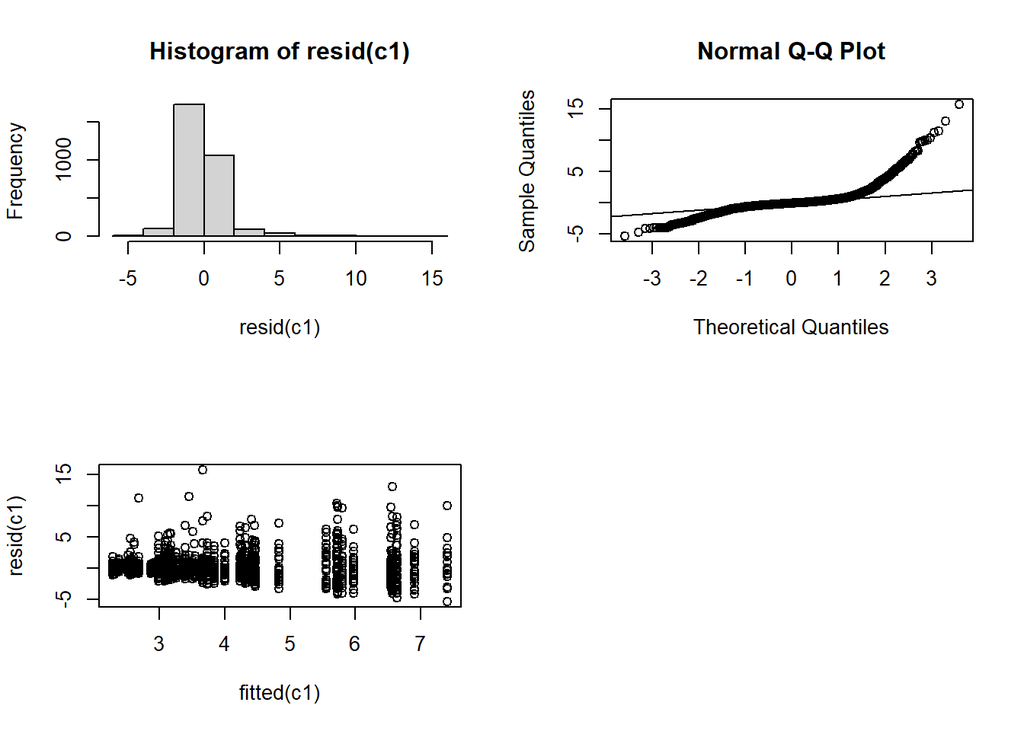

```r
par(mfrow=c(2, 2))
hist(resid(c1))
qqnorm(resid(c1));qqline(resid(c1))
plot(fitted(c1), resid(c1))
```

### Inhalation Amplitude

```r
dat <- brm %>%
  filter(Role=="Participant", act == "listening")
```

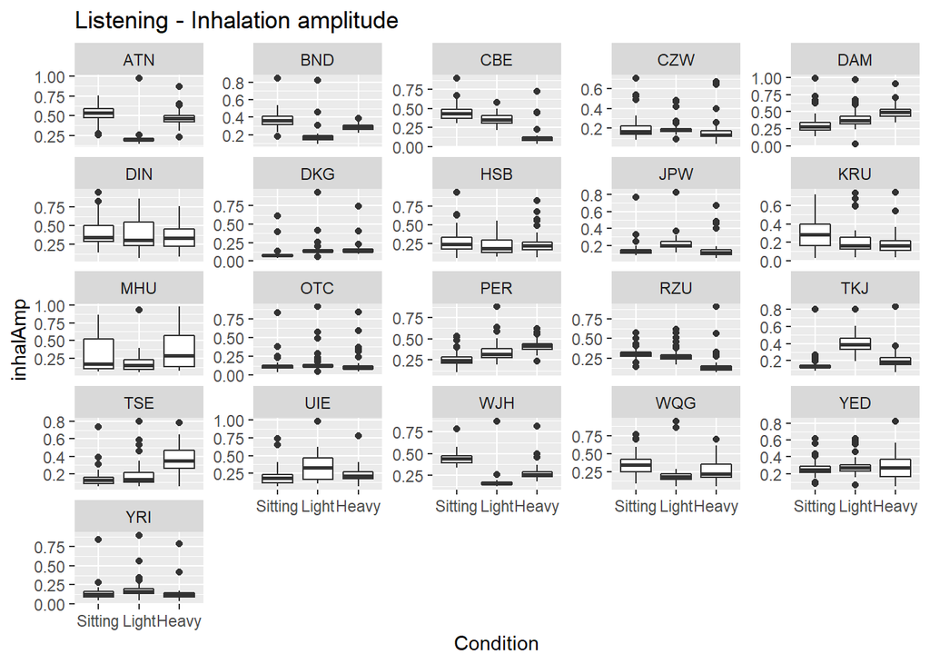

```r
ggplot(dat, aes(Condition, inhalAmp))+
  geom_boxplot()+
  facet_wrap(~Speaker, scales="free_y")+
  ggtitle("Listening - Inhalation amplitude")
```

```r
ggsave(paste0(folderInd, "Listening-InhalAmp-Conditions.png"), width = 3000, height=3000, units="px")
```

For a couple of participants there was a clear in- or decrease in inhalation amplitude with physical effort. For some, non-linear effect (markedly). For the others, no difference.

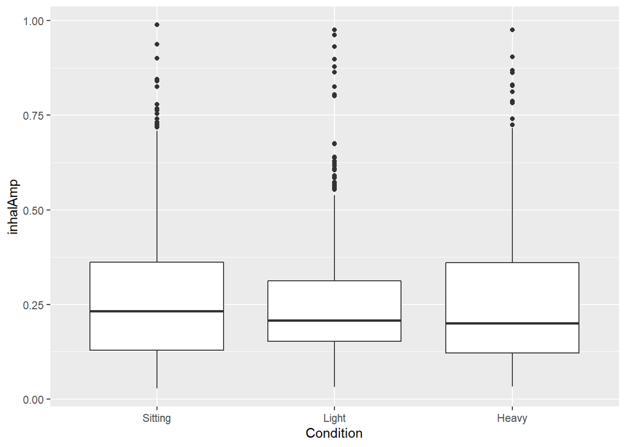

```r
ggplot(dat %>% filter(cycleDur < 7), aes(Condition, inhalAmp))+
  geom_boxplot()
```

- Inhalation amplitude doesn’t change across conditions during listening.

```r
summary(c1 <- lmer(inhalAmp ~ Condition + (1 + Condition |Speaker), dat))
```

```
## Linear mixed model fit by REML ['lmerMod']
## Formula: inhalAmp ~ Condition + (1 + Condition | Speaker)
##    Data: dat
##
## REML criterion at convergence: -3793.4
##
## Scaled residuals:
##     Min      1Q  Median      3Q     Max
## -2.8169 -0.4569 -0.1760  0.1846  6.1354
##
## Random effects:
##  Groups   Name           Variance Std.Dev. Corr
##  Speaker  (Intercept)    0.01410  0.1187
##           ConditionLight 0.01696  0.1302   -0.79
##           ConditionHeavy 0.01432  0.1197   -0.57  0.56
##  Residual                0.01578  0.1256
## Number of obs: 3066, groups:  Speaker, 21
##
## Fixed effects:
##                 Estimate Std. Error t value
## (Intercept)     0.274209   0.026195  10.468
## ConditionLight -0.019568   0.028957  -0.676
## ConditionHeavy -0.007846   0.026794  -0.293
##
## Correlation of Fixed Effects:
##             (Intr) CndtnL
## ConditnLght -0.790
## ConditinHvy -0.566  0.551
```

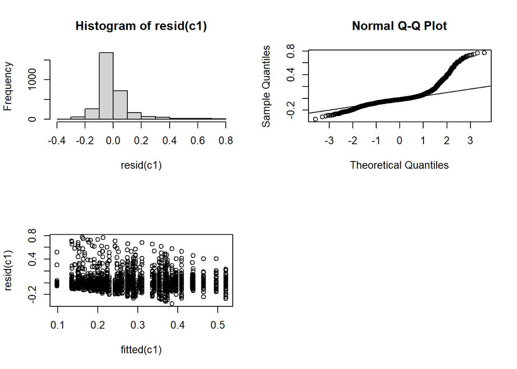

```r
par(mfrow=c(2, 2))
hist(resid(c1))
qqnorm(resid(c1));qqline(resid(c1))
plot(fitted(c1), resid(c1))
```

# 2 - Speech without overlap

# 2.1 Do speakers adapt their speech (f0) to an interlocutor who moves with different physical effort?

## Solo read speech

```r
dat <- frb %>%
  filter(Role=="Participant", Task=="ReadAlone")
```

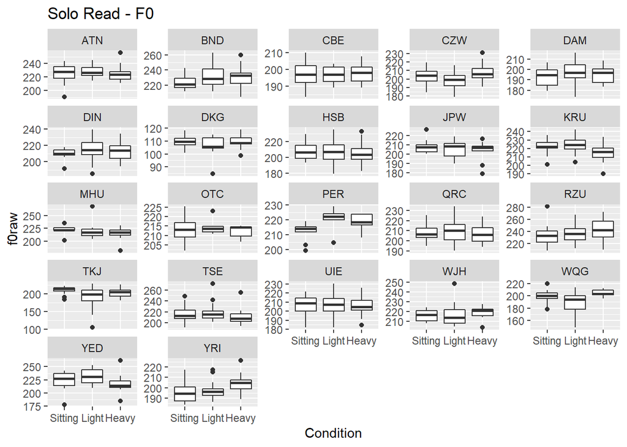

```r
ggplot(dat, aes(Condition, f0raw))+
  geom_boxplot()+
  facet_wrap(~Speaker, scales="free_y")+
  ggtitle("Solo Read - F0")
```

```r
ggsave(paste0(folderInd, "SoloRead-F0-Conditions.png"), width = 3000, height=3000, units="px")
```

For a couple of participants, increase with condition. In general, no difference.

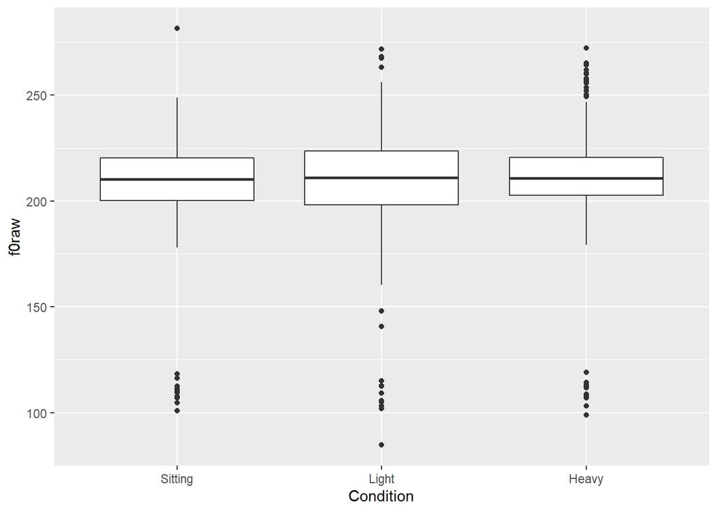

```r
ggplot(dat, aes(Condition, f0raw))+
  geom_boxplot()
```

- F0 didn’t change across conditions during solo read speech.

```r
summary(f1 <- lmer(f0raw ~ Condition + (1 + Condition | Speaker), dat))
```

```
## Linear mixed model fit by REML ['lmerMod']
## Formula: f0raw ~ Condition + (1 + Condition | Speaker)
##    Data: dat
##
## REML criterion at convergence: 16025.9
##
## Scaled residuals:
##     Min      1Q  Median      3Q     Max
## -7.2869 -0.5974  0.0154  0.5419  4.4266
##
## Random effects:
##  Groups   Name           Variance Std.Dev. Corr
##  Speaker  (Intercept)    573.43   23.946
##           ConditionLight  32.61    5.711    0.32
##           ConditionHeavy  20.63    4.542   -0.03  0.24
##  Residual                142.92   11.955
## Number of obs: 2032, groups:  Speaker, 22
##
## Fixed effects:
##                Estimate Std. Error t value
## (Intercept)    207.2131     5.1291  40.399
## ConditionLight   0.0664     1.3980   0.047
## ConditionHeavy   0.1274     1.1859   0.107
##
## Correlation of Fixed Effects:
##             (Intr) CndtnL
## ConditnLght  0.243
## ConditinHvy -0.065  0.318
```

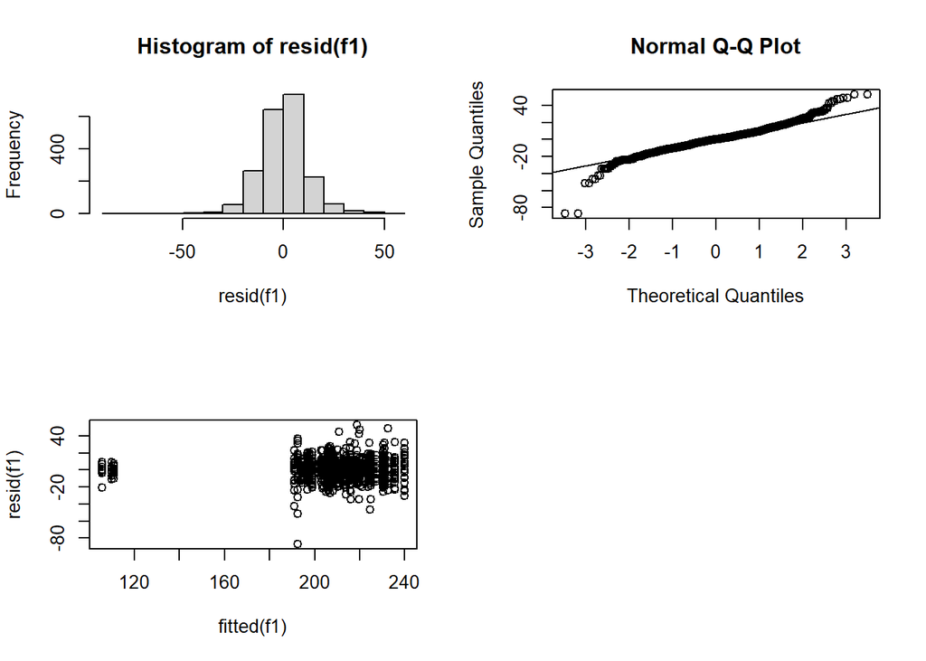

```r
par(mfrow=c(2, 2))
hist(resid(f1))
qqnorm(resid(f1));qqline(resid(f1))
plot(fitted(f1), resid(f1))
```

## Solo spontaneous speech

```r
dat <- fsm %>%
  filter(Role=="Participant", Task=="Free", Condition!="Baseline")
```

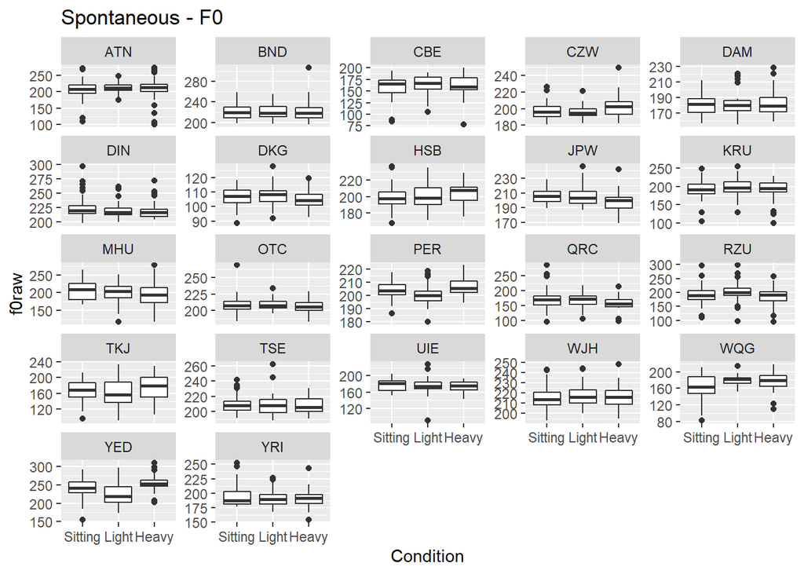

```r
ggplot(dat, aes(Condition, f0raw))+
  geom_boxplot()+
  facet_wrap(~Speaker, scales="free_y")+
  ggtitle("Spontaneous - F0")
```

```r
ggsave(paste0(folderInd, "Spontaneous-F0-Conditions.png"), width = 3000, height=3000, units="px")
```

No difference.

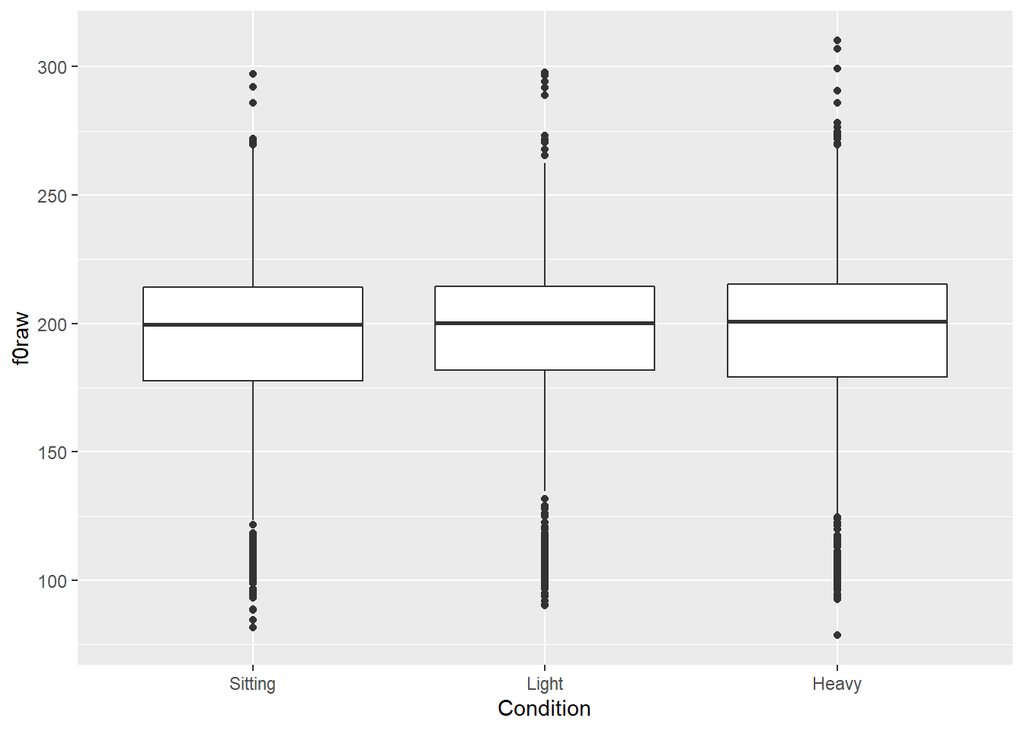

```r
ggplot(dat, aes(Condition, f0raw))+
  geom_boxplot()
```

- F0 didn’t change across conditions during solo free speech.

```r
summary(f1 <- lmer(f0raw ~ Condition + (1 + Condition | Speaker), dat))
```

```
## Linear mixed model fit by REML ['lmerMod']
## Formula: f0raw ~ Condition + (1 + Condition | Speaker)
##    Data: dat
##
## REML criterion at convergence: 28160.3
##
## Scaled residuals:
##     Min      1Q  Median      3Q     Max
## -5.3356 -0.4756 -0.0251  0.4812  5.6886
##
## Random effects:
##  Groups   Name           Variance Std.Dev. Corr
##  Speaker  (Intercept)    779.57   27.921
##           ConditionLight  21.41    4.627   -0.30
##           ConditionHeavy  24.98    4.998    0.13 -0.36
##  Residual                419.09   20.472
## Number of obs: 3156, groups:  Speaker, 22
##
## Fixed effects:
##                 Estimate Std. Error t value
## (Intercept)    192.94453    5.98812  32.221
## ConditionLight  -0.24963    1.36169  -0.183
## ConditionHeavy  -0.09124    1.41975  -0.064
##
## Correlation of Fixed Effects:
##             (Intr) CndtnL
## ConditnLght -0.269
## ConditinHvy  0.045  0.015
```

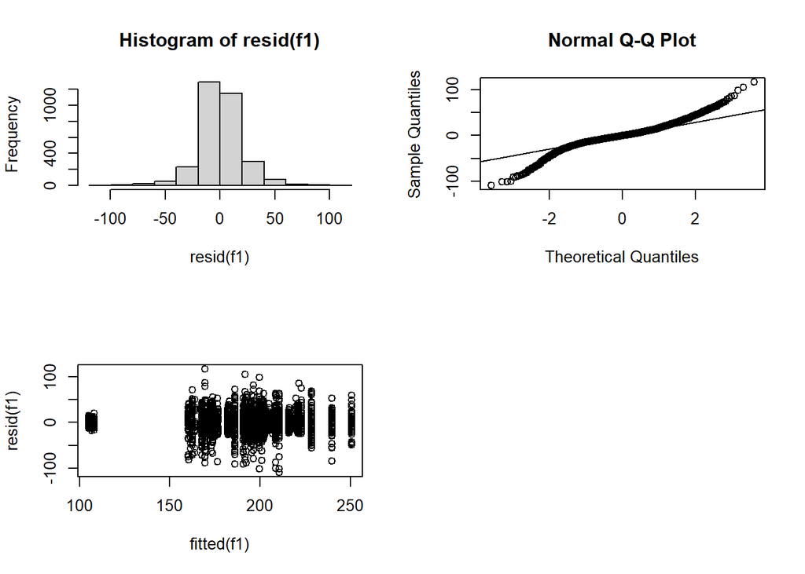

```r
par(mfrow=c(2, 2))
hist(resid(f1))
qqnorm(resid(f1));qqline(resid(f1))
plot(fitted(f1), resid(f1))
```

# 3 - Breathing during synchronous speech

# 3.1 Do speakers adapt their breathing while reading synchronously with an interlocutor in comparison to an interaction with no overlap?

### Cycle Duration

```r
dat <- brm %>%
  filter(Role=="Participant", Task %in% c("ReadJoint", "ReadAlone"))
```

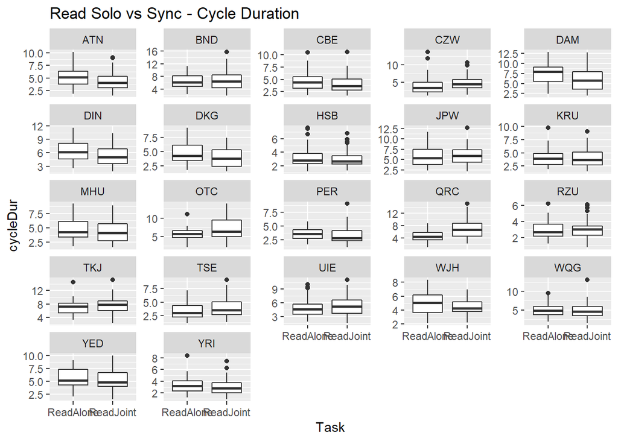

```r
ggplot(dat, aes(Task, cycleDur))+
  geom_boxplot()+
  facet_wrap(~Speaker, scales="free_y")+
  ggtitle("Read Solo vs Sync - Cycle Duration")
```

```r
ggsave(paste0(folderInd, "SoloSync-CycleDur-Task.png"), width = 3000, height=3000, units="px")
```

For a few, shorter cycles during sync read speech. In general, no difference.

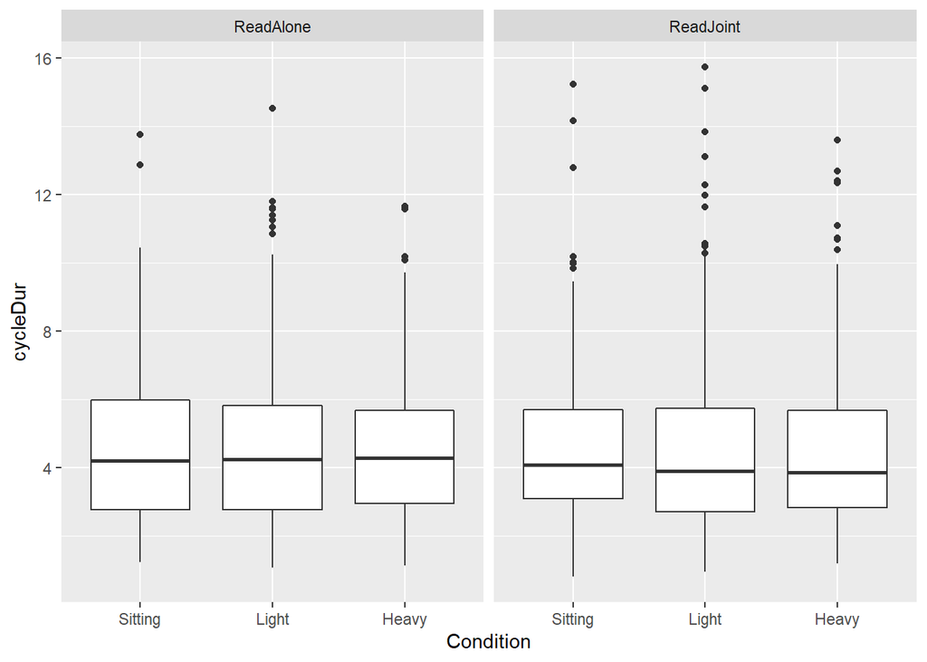

```r
ggplot(dat, aes(Condition, cycleDur))+
  geom_boxplot()+
  facet_wrap(~Task)
```

- There is no effect of task (solo vs. synchronous) on cycle duration. And no interaction with condition.

```r
# dat$Condition <- relevel(dat$Condition, ref="Light")

summary(b1 <- lmer(cycleDur ~ Task + (1+Task | Speaker), dat))
```

```
## Linear mixed model fit by REML ['lmerMod']
## Formula: cycleDur ~ Task + (1 + Task | Speaker)
##    Data: dat
##
## REML criterion at convergence: 7644.2
##
## Scaled residuals:
##     Min      1Q  Median      3Q     Max
## -2.6754 -0.6570 -0.1242  0.5327  5.0439
##
## Random effects:
##  Groups   Name          Variance Std.Dev. Corr
##  Speaker  (Intercept)   1.4766   1.2151
##           TaskReadJoint 0.5672   0.7531   -0.08
##  Residual               3.7050   1.9248
## Number of obs: 1817, groups:  Speaker, 22
##
## Fixed effects:
##               Estimate Std. Error t value
## (Intercept)    4.89520    0.26794  18.270
## TaskReadJoint -0.02507    0.18565  -0.135
##
## Correlation of Fixed Effects:
##             (Intr)
## TaskReadJnt -0.163
```

```r
summary(b1a <- lmer(cycleDur ~ Task:Condition + (1+Task+Condition | Speaker), dat))
```

```
## Linear mixed model fit by REML ['lmerMod']
## Formula: cycleDur ~ Task:Condition + (1 + Task + Condition | Speaker)
##    Data: dat
##
## REML criterion at convergence: 7642.2
##
## Scaled residuals:
##     Min      1Q  Median      3Q     Max
## -2.9256 -0.6525 -0.1222  0.5358  4.7334
##
## Random effects:
##  Groups   Name           Variance Std.Dev. Corr
##  Speaker  (Intercept)    1.3884   1.1783
##           TaskReadJoint  0.5631   0.7504   -0.14
##           ConditionLight 0.1549   0.3936    0.24  0.28
##           ConditionHeavy 0.2838   0.5327   -0.15  0.11  0.89
##  Residual                3.6614   1.9135
## Number of obs: 1817, groups:  Speaker, 22
##
## Fixed effects:
##                                Estimate Std. Error t value
## (Intercept)                     4.80268    0.31052  15.467
## TaskReadAlone:ConditionSitting  0.04351    0.25769   0.169
## TaskReadJoint:ConditionSitting  0.06456    0.19077   0.338
## TaskReadAlone:ConditionLight    0.19866    0.22047   0.901
## TaskReadJoint:ConditionLight    0.17176    0.15609   1.100
## TaskReadAlone:ConditionHeavy    0.07568    0.22158   0.342
##
## Correlation of Fixed Effects:
##             (Intr) TRA:CS TRJ:CS TRA:CL TRJ:CL
## TskRdAln:CS -0.539
## TskRdJnt:CS -0.351  0.515
## TskRdAln:CL -0.373  0.715  0.393
## TskRdJnt:CL -0.066  0.315  0.489  0.323
## TskRdAln:CH -0.470  0.665  0.285  0.701  0.236
## fit warnings:
## fixed-effect model matrix is rank deficient so dropping 1 column / coefficient
## optimizer (nloptwrap) convergence code: 0 (OK)
## boundary (singular) fit: see help('isSingular')
```

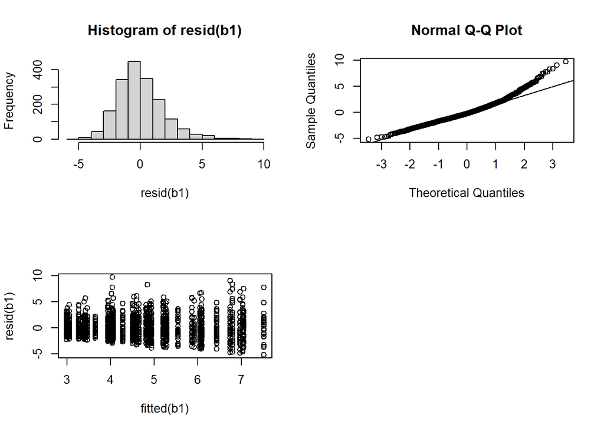

```r
par(mfrow=c(2, 2))
hist(resid(b1))
qqnorm(resid(b1));qqline(resid(b1))
plot(fitted(b1), resid(b1))
```

### Inhalation Amplitude

```r
dat <- brm %>%
  filter(Role=="Participant", Task %in% c("ReadJoint", "ReadAlone"))
```

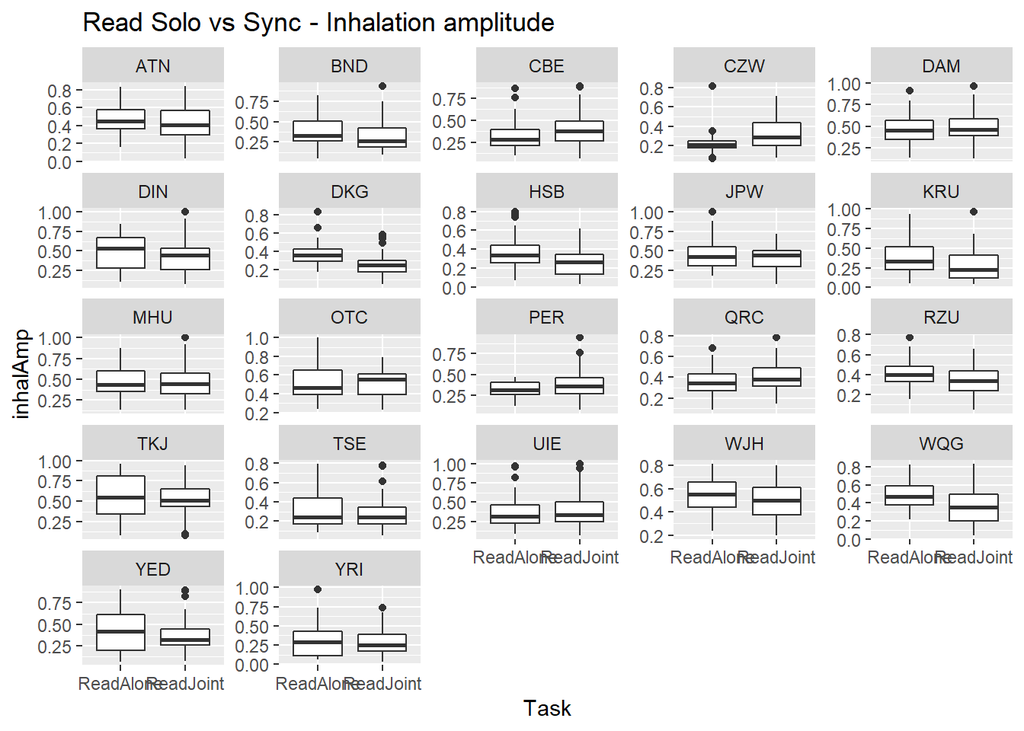

```r
ggplot(dat, aes(Task, inhalAmp))+
  geom_boxplot()+
  facet_wrap(~Speaker, scales="free_y")+
  ggtitle("Read Solo vs Sync - Inhalation amplitude")
```

```r
ggsave(paste0(folderInd, "SoloSync-InhalAmp-Task.png"), width = 3000, height=3000, units="px")
```

No difference.

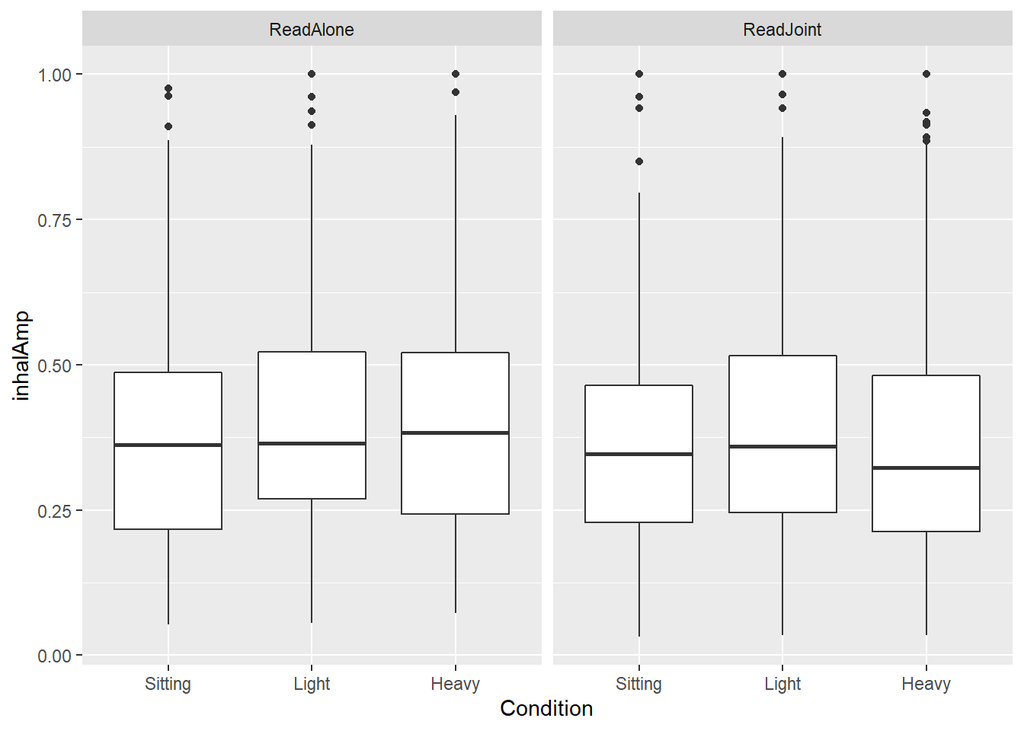

```r
ggplot(dat, aes(Condition, inhalAmp))+
  geom_boxplot()+
  facet_wrap(~Task)
```

- Inhalation amplitude was lower while reading synchronously than while reading solo. See model below for the interaction with Condition.

```r
# dat$Condition <- relevel(dat$Condition, ref="Light")

summary(b1 <- lmer(inhalAmp ~ Task + (1+Task | Speaker), dat))
```

```
## Linear mixed model fit by REML ['lmerMod']
## Formula: inhalAmp ~ Task + (1 + Task | Speaker)
##    Data: dat
##
## REML criterion at convergence: -1004.5
##
## Scaled residuals:
##     Min      1Q  Median      3Q     Max
## -2.5551 -0.6846 -0.1301  0.5704  3.7186
##
## Random effects:
##  Groups   Name          Variance Std.Dev. Corr
##  Speaker  (Intercept)   0.006428 0.08017
##           TaskReadJoint 0.002233 0.04726  -0.34
##  Residual               0.032053 0.17903
## Number of obs: 1817, groups:  Speaker, 22
##
## Fixed effects:
##               Estimate Std. Error t value
## (Intercept)    0.41095    0.01823   22.54
## TaskReadJoint -0.03023    0.01326   -2.28
##
## Correlation of Fixed Effects:
##             (Intr)
## TaskReadJnt -0.406
```

```r
summary(b1a <- lmer(inhalAmp ~ Task:Condition + (1+Task +Condition| Speaker), dat))
```

```
## Linear mixed model fit by REML ['lmerMod']
## Formula: inhalAmp ~ Task:Condition + (1 + Task + Condition | Speaker)
##    Data: dat
##
## REML criterion at convergence: -1021.8
##
## Scaled residuals:
##     Min      1Q  Median      3Q     Max
## -2.4527 -0.6804 -0.1260  0.5669  3.9805
##
## Random effects:
##  Groups   Name           Variance Std.Dev. Corr
##  Speaker  (Intercept)    0.005593 0.07479
##           TaskReadJoint  0.002323 0.04819  -0.28
##           ConditionLight 0.002389 0.04888  -0.21  0.26
##           ConditionHeavy 0.004393 0.06628   0.09 -0.45  0.40
##  Residual                0.030738 0.17532
## Number of obs: 1817, groups:  Speaker, 22
##
## Fixed effects:
##                                Estimate Std. Error t value
## (Intercept)                     0.37489    0.02161  17.349
## TaskReadAlone:ConditionSitting  0.01794    0.01936   0.927
## TaskReadJoint:ConditionSitting -0.01066    0.01994  -0.534
## TaskReadAlone:ConditionLight    0.04567    0.01764   2.589
## TaskReadJoint:ConditionLight    0.03106    0.01940   1.601
## TaskReadAlone:ConditionHeavy    0.05002    0.01738   2.878
##
## Correlation of Fixed Effects:
##             (Intr) TRA:CS TRJ:CS TRA:CL TRJ:CL
## TskRdAln:CS -0.567
## TskRdJnt:CS -0.562  0.576
## TskRdAln:CL -0.487  0.514  0.461
## TskRdJnt:CL -0.454  0.355  0.589  0.543
## TskRdAln:CH -0.212  0.375  0.054  0.320 -0.030
## fit warnings:
## fixed-effect model matrix is rank deficient so dropping 1 column / coefficient
```

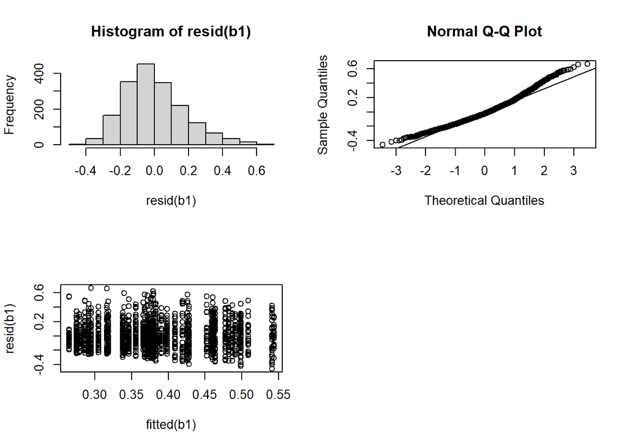

```r
par(mfrow=c(2, 2))
hist(resid(b1))
qqnorm(resid(b1));qqline(resid(b1))
plot(fitted(b1), resid(b1))
```

# 3.2 Do speakers adapt their breathing while reading synchronously with an interlocutor who moves and talks under different physical effort?

### Cycle Duration

```r
dat <- brm %>%
  filter(Role=="Participant", Task=="ReadJoint")
```

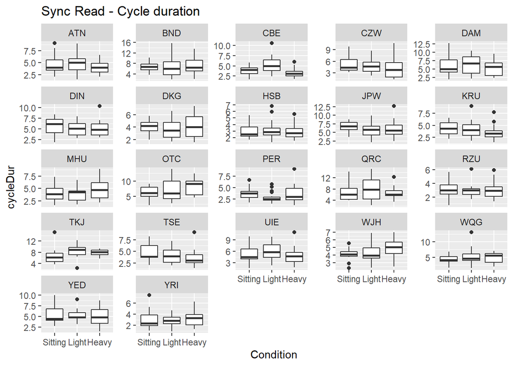

```r
ggplot(dat, aes(Condition, cycleDur))+
  geom_boxplot()+
  facet_wrap(~Speaker, scales="free_y")+
  ggtitle("Sync Read - Cycle duration")
```

```r
ggsave(paste0(folderInd, "SyncRead-CycleDur-Conditions.png"), width = 3000, height=3000, units="px")
```

Slight change in cycle duration across condition for a couple of participants. In general, no difference.

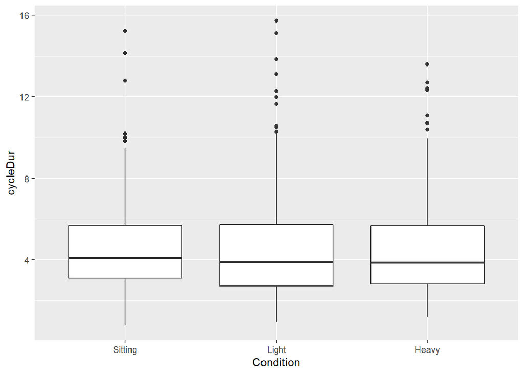

```r
ggplot(dat, aes(Condition, cycleDur))+
  geom_boxplot()
```

- Cycle durations didn’t change across conditions during synchronous read speech.

```r
# dat$Condition <- relevel(dat$Condition, ref="Light")

summary(b1 <- lmer(cycleDur ~ Condition + (1 +Condition| Speaker), dat))
```

```
## Linear mixed model fit by REML ['lmerMod']
## Formula: cycleDur ~ Condition + (1 + Condition | Speaker)
##    Data: dat
##
## REML criterion at convergence: 4140.2
##
## Scaled residuals:
##     Min      1Q  Median      3Q     Max
## -2.8288 -0.6292 -0.1272  0.5202  4.5576
##
## Random effects:
##  Groups   Name           Variance Std.Dev. Corr
##  Speaker  (Intercept)    1.48415  1.2183
##           ConditionLight 0.09598  0.3098   0.95
##           ConditionHeavy 0.09133  0.3022   0.61 0.33
##  Residual                3.76972  1.9416
## Number of obs: 976, groups:  Speaker, 22
##
## Fixed effects:
##                Estimate Std. Error t value
## (Intercept)     4.84024    0.28468  17.003
## ConditionLight  0.13856    0.17212   0.805
## ConditionHeavy -0.02386    0.16752  -0.142
##
## Correlation of Fixed Effects:
##             (Intr) CndtnL
## ConditnLght  0.060
## ConditinHvy -0.068  0.512
```

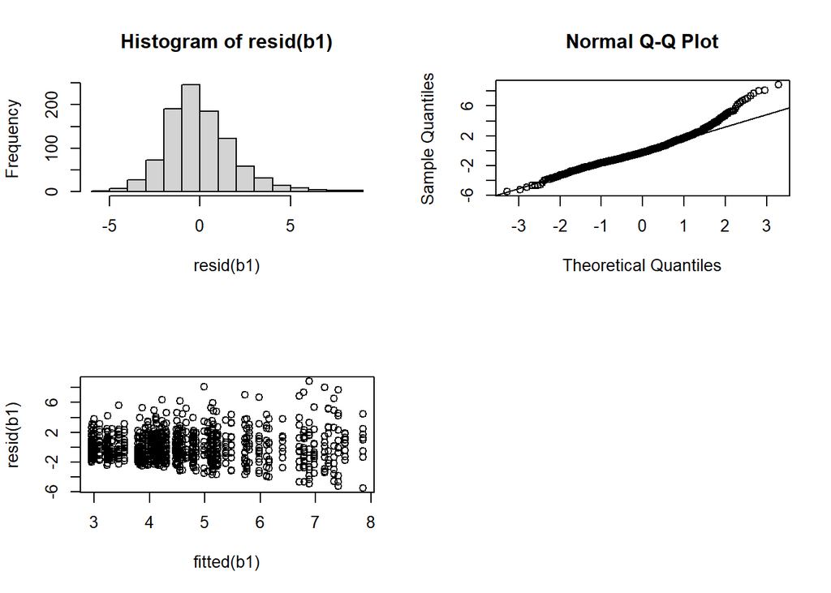

```r
par(mfrow=c(2, 2))
hist(resid(b1))
qqnorm(resid(b1));qqline(resid(b1))
plot(fitted(b1), resid(b1))
```

### Inhalation Amplitude

```r
dat <- brm %>%
  filter(Role=="Participant", Task=="ReadJoint")
```

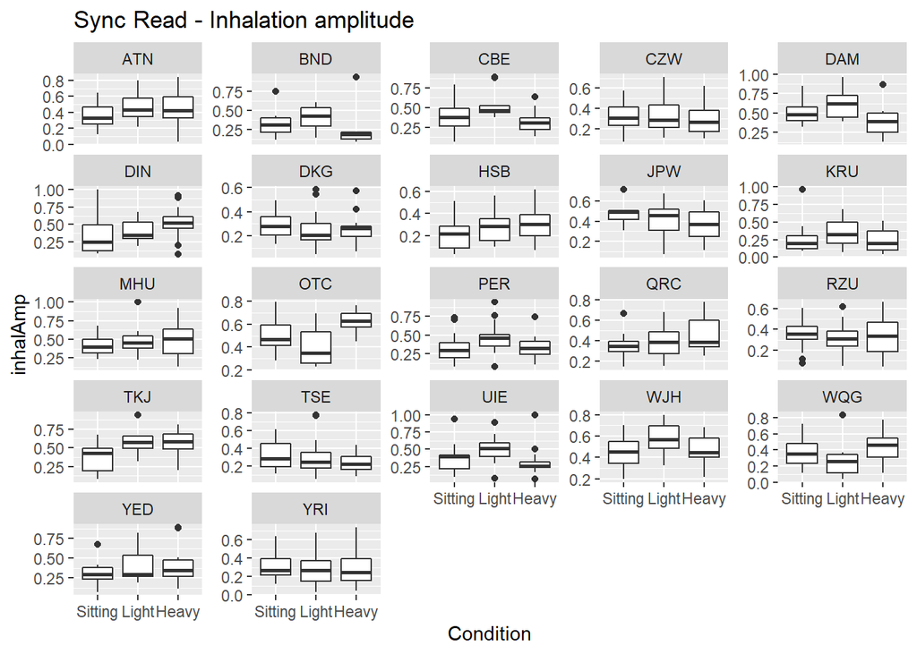

```r
ggplot(dat, aes(Condition, inhalAmp))+
  geom_boxplot()+
  facet_wrap(~Speaker, scales="free_y")+
  ggtitle("Sync Read - Inhalation amplitude")
```

```r
ggsave(paste0(folderInd, "SyncRead-InhalAmp-Conditions.png"), width = 3000, height=3000, units="px")
```

For a few, in- or decrease with condition; others, a clear non-linear effect. For many, no difference.

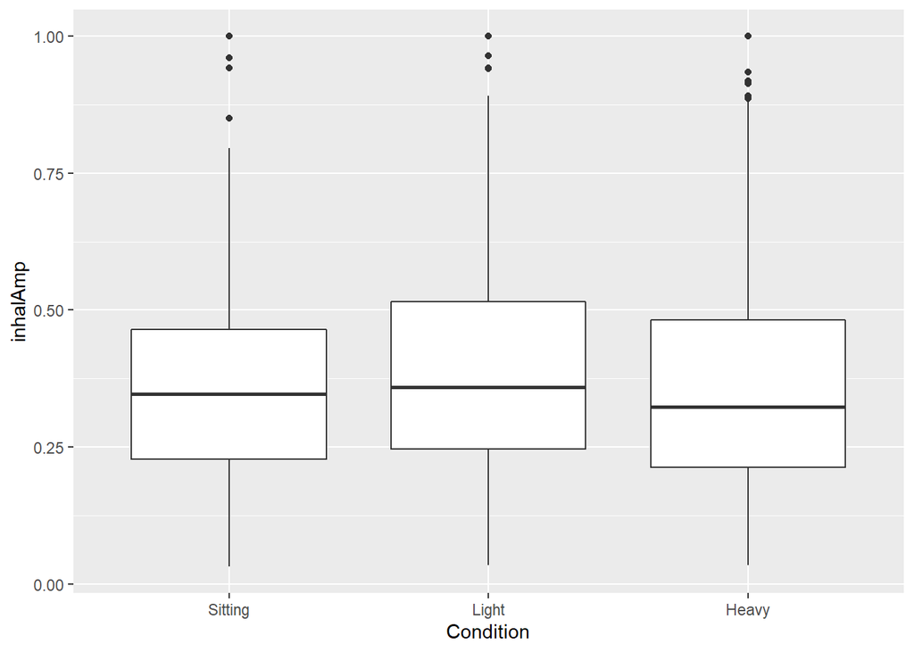

```r
ggplot(dat, aes(Condition, inhalAmp))+
  geom_boxplot()
```

- Inhalation amplitude was larger during Light Biking than during Sitting and Heavy Biking. No difference between Sitting and Heavy Biking.

```r
# dat$Condition <- relevel(dat$Condition, ref="Light")

summary(b1 <- lmer(inhalAmp ~ Condition + (1 | Speaker), dat))
```

```
## Linear mixed model fit by REML ['lmerMod']
## Formula: inhalAmp ~ Condition + (1 | Speaker)
##    Data: dat
##
## REML criterion at convergence: -549.7
##
## Scaled residuals:
##     Min      1Q  Median      3Q     Max
## -2.2265 -0.7211 -0.1123  0.6022  3.9112
##
## Random effects:
##  Groups   Name        Variance Std.Dev.
##  Speaker  (Intercept) 0.006131 0.0783
##  Residual             0.031148 0.1765
## Number of obs: 976, groups:  Speaker, 22
##
## Fixed effects:
##                Estimate Std. Error t value
## (Intercept)    0.363338   0.019779  18.370
## ConditionLight 0.040945   0.014406   2.842
## ConditionHeavy 0.009926   0.014010   0.709
##
## Correlation of Fixed Effects:
##             (Intr) CndtnL
## ConditnLght -0.388
## ConditinHvy -0.399  0.550
```

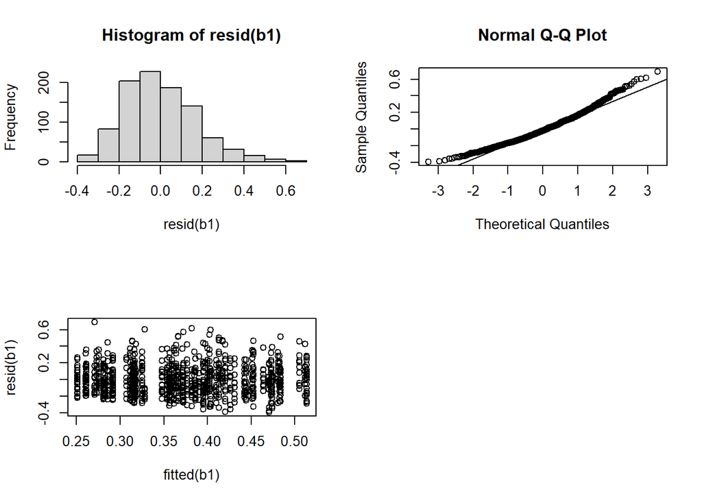

```r
par(mfrow=c(2, 2))
hist(resid(b1))
qqnorm(resid(b1));qqline(resid(b1))
plot(fitted(b1), resid(b1))
```

# 3 - Synchronous speech

# 3.1 Do speakers adapt their speech (f0) while reading synchronously with an interlocutor in comparison to an interaction with no overlap?

```r
dat <- frb %>%
  filter(Role=="Participant", Task %in% c("ReadJoint", "ReadAlone"))
```

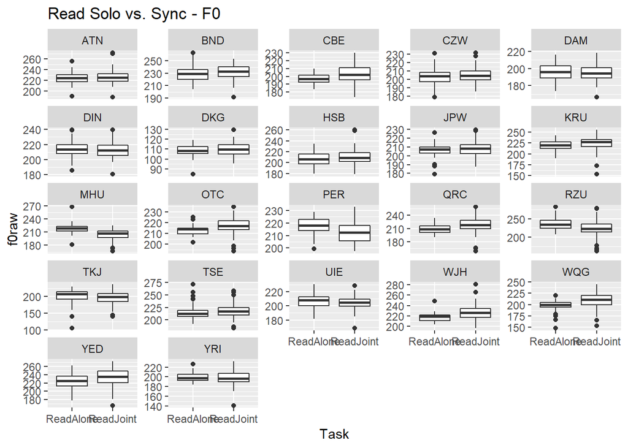

```r
ggplot(dat, aes(Task, f0raw))+
  geom_boxplot()+
  facet_wrap(~Speaker, scales="free_y")+
  ggtitle("Read Solo vs. Sync - F0")
```

```r
ggsave(paste0(folderInd, "SyncRead-F0-Task.png"), width = 3000, height=3000, units="px")
```

For a few, higher f0 during sync read speech; for a couple, the opposite. In general, no difference.

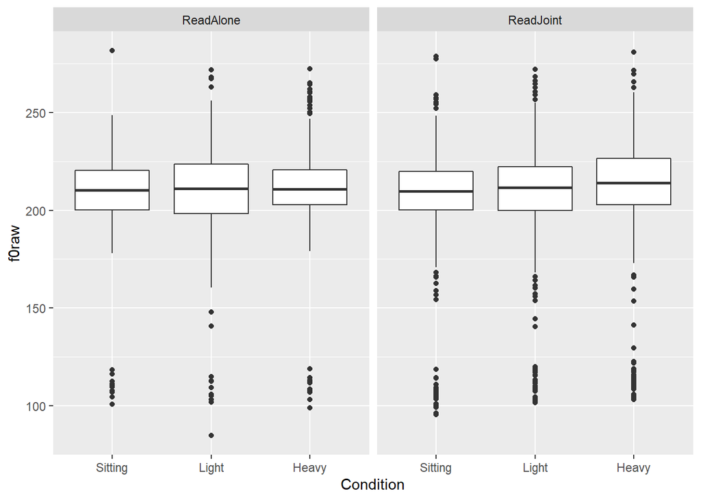

```r
ggplot(dat, aes(Condition, f0raw))+
  geom_boxplot()+
  facet_wrap(~Task)
```

- There is no effect of task (solo vs. synchronous) on f0. See model below for the interaction with condition.

```r
# dat$Condition <- relevel(dat$Condition, ref="Light")

summary(b1 <- lmer(f0raw ~ Task + (1+Task | Speaker), dat))
```

```
## Linear mixed model fit by REML ['lmerMod']
## Formula: f0raw ~ Task + (1 + Task | Speaker)
##    Data: dat
##
## REML criterion at convergence: 45775.9
##
## Scaled residuals:
##     Min      1Q  Median      3Q     Max
## -7.1882 -0.5353  0.0127  0.5607  4.2801
##
## Random effects:
##  Groups   Name          Variance Std.Dev. Corr
##  Speaker  (Intercept)   609.07   24.679
##           TaskReadJoint  40.09    6.331   -0.11
##  Residual               177.35   13.317
## Number of obs: 5686, groups:  Speaker, 22
##
## Fixed effects:
##               Estimate Std. Error t value
## (Intercept)    207.237      5.271  39.318
## TaskReadJoint    1.299      1.403   0.926
##
## Correlation of Fixed Effects:
##             (Intr)
## TaskReadJnt -0.121
```

```r
summary(b1 <- lmer(f0raw ~ Task:Condition + (1+Task+Condition | Speaker), dat))
```

```
## Linear mixed model fit by REML ['lmerMod']
## Formula: f0raw ~ Task:Condition + (1 + Task + Condition | Speaker)
##    Data: dat
##
## REML criterion at convergence: 45570
##
## Scaled residuals:
##     Min      1Q  Median      3Q     Max
## -6.7832 -0.5468  0.0131  0.5548  4.6508
##
## Random effects:
##  Groups   Name           Variance Std.Dev. Corr
##  Speaker  (Intercept)    594.58   24.384
##           TaskReadJoint   41.53    6.444   -0.09
##           ConditionLight  18.35    4.284    0.18 -0.04
##           ConditionHeavy  11.29    3.361   -0.05 -0.46  0.13
##  Residual                169.25   13.010
## Number of obs: 5686, groups:  Speaker, 22
##
## Fixed effects:
##                                Estimate Std. Error t value
## (Intercept)                    210.6290     5.1889  40.592
## TaskReadAlone:ConditionSitting  -3.3278     1.3780  -2.415
## TaskReadJoint:ConditionSitting  -4.4924     0.9053  -4.962
## TaskReadAlone:ConditionLight    -3.4781     1.6295  -2.135
## TaskReadJoint:ConditionLight    -2.6950     1.1991  -2.247
## TaskReadAlone:ConditionHeavy    -3.4007     1.5058  -2.258
##
## Correlation of Fixed Effects:
##             (Intr) TRA:CS TRJ:CS TRA:CL TRJ:CL
## TskRdAln:CS -0.106
## TskRdJnt:CS  0.002  0.148
## TskRdAln:CL  0.015  0.710  0.066
## TskRdJnt:CL  0.144  0.092  0.505  0.463
## TskRdAln:CH -0.114  0.752 -0.243  0.659 -0.154
## fit warnings:
## fixed-effect model matrix is rank deficient so dropping 1 column / coefficient
```

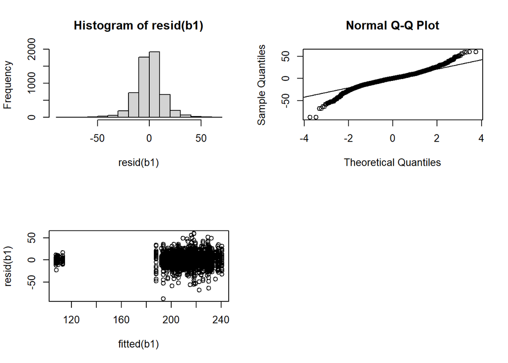

```r
par(mfrow=c(2, 2))
hist(resid(b1))
qqnorm(resid(b1));qqline(resid(b1))
plot(fitted(b1), resid(b1))
```

# 3.2 Do speakers adapt their speech (f0) while reading synchronously with an interlocutor who moves and talks under different physical effort?

```r
dat <- frb %>%
  filter(Role=="Participant", Task=="ReadJoint")
```

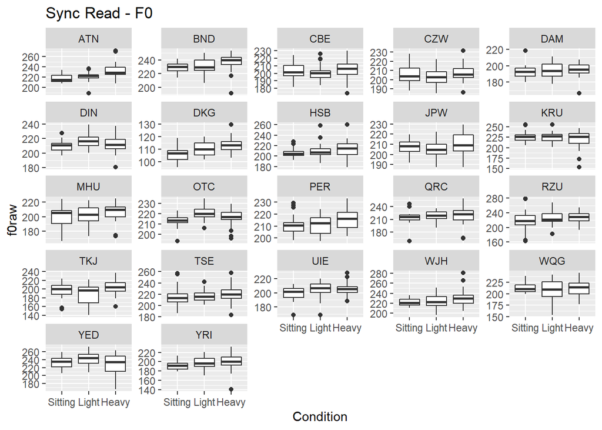

```r
ggplot(dat, aes(Condition, f0raw))+
  geom_boxplot()+
  facet_wrap(~Speaker, scales="free_y")+
  ggtitle("Sync Read - F0")
```

```r
ggsave(paste0(folderInd, "SyncRead-F0-Conditions.png"), width = 3000, height=3000, units="px")
```

For most, increase with condition.

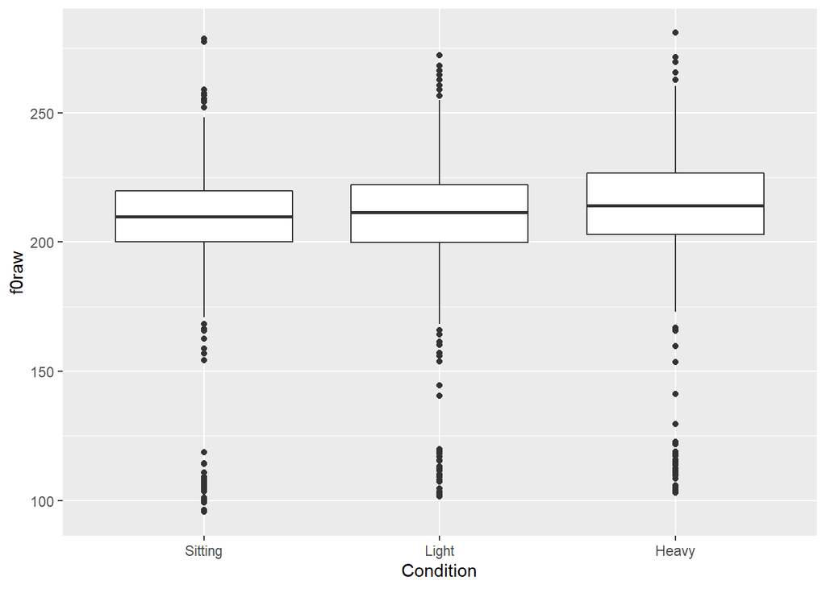

```r
ggplot(dat, aes(Condition, f0raw))+
  geom_boxplot()
```

- F0 is higher during Heavy Biking than Sitting or Light Biking.
- There is no significant difference between Light and Sitting, but a tendency for Light to have higher f0 (following the pattern).

```r
# dat$Condition <- relevel(dat$Condition, ref="Light")

summary(b1 <- lmer(f0raw ~ Condition + (1 + Condition | Speaker), dat))
```

```
## Linear mixed model fit by REML ['lmerMod']
## Formula: f0raw ~ Condition + (1 + Condition | Speaker)
##    Data: dat
##
## REML criterion at convergence: 29560.9
##
## Scaled residuals:
##     Min      1Q  Median      3Q     Max
## -5.1195 -0.5334  0.0266  0.5384  4.4278
##
## Random effects:
##  Groups   Name           Variance Std.Dev. Corr
##  Speaker  (Intercept)    621.45   24.929
##           ConditionLight  13.30    3.647    0.04
##           ConditionHeavy  13.18    3.630   -0.22 -0.01
##  Residual                181.78   13.483
## Number of obs: 3654, groups:  Speaker, 22
##
## Fixed effects:
##                Estimate Std. Error t value
## (Intercept)    206.1112     5.3341  38.641
## ConditionLight   1.7052     0.9784   1.743
## ConditionHeavy   4.4910     0.9644   4.657
##
## Correlation of Fixed Effects:
##             (Intr) CndtnL
## ConditnLght -0.011
## ConditinHvy -0.219  0.208
```

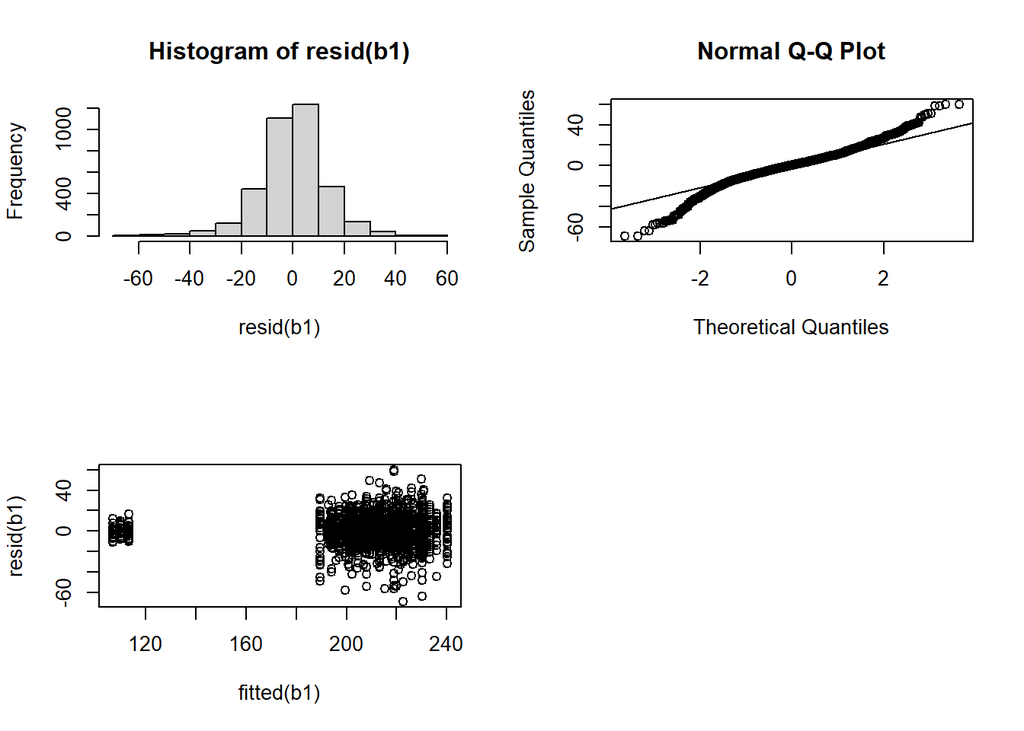

```r
par(mfrow=c(2, 2))
hist(resid(b1))
qqnorm(resid(b1));qqline(resid(b1))
plot(fitted(b1), resid(b1))
```